# Early childhood factors and health pathways to disability and death in mid-ages — a multi-state time-to-event model

The paper studies how early childhood factors and health behaviors are related to incidence of chronic diseases, disability, and death in mid-ages in a multi-state time to event model.

Author

Affiliation

Lakshmi K. Raut

Visiting Fellow, CEHD, University of Chicago

Published

November 4, 2024

Abstract

*Developmental programming* literature in microbiology emphasizes that much of the process of health development throughout life is determined at early stages of life by the early childhood epigenetic factors comprised of internal and external environments, health care use, health related behavior, and by the genetic makeup. This paper introduces and empirically estimates a statistical multi-state time-to-event event history model of incidence of chronic diseases, disability, and death at mid-ages, incorporating childhood factors and health behaviors. Many of the factors at the cellular level are unobserved or imperfectly instrumented with observed data, which causes unobserved heterogeneity biases in parameter estimates of included regressors. This paper corrects for unobserved heterogeneity biases, extending statistical techniques from the generally studied two-state models to the multi-state model of this paper. The paper uses the HRS (Health and Retirement Studies) dataset, takes the definition of disability as the health status qualifying for the Social Security’s DI (Disability Insurance) program or the SSI (Supplemental Security Income) program. The paper studies how various childhood factors and health behaviors are associated with probabilities of following various transition paths through the health states of normal health, illness with one-or-more chronic diseases, culminating in disability or death by age 65. The paper also carries out quantitative policy analysis of social policies improving childhood factors of various social groups on their probabilities of maintaining good health, encountering disability or death in mid-ages.  
**JEL Classifications:** I12, C41, C51.  
**Keywords:** Disease incidence, Disability, Mortality, Aging, Multistate time-to-event model,Unobserved heterogeneity.

**Acknowledgment and disclaimer**[^1]

# 1 Introduction

Identification of factors that determine disability and mortality incidence rates is important for disability programs such as Social Security Disability Insurance (DI) and the Supplemental Security Income (SSI) programs. According to the biology of living organisms, all individuals succumb to aging, and experience diseases and disabilities of various kinds as they age. The consensus in the microbiology literature is that the process of health development throughout life is determined at early stages of life by the early childhood epigenetic factors comprised of internal and external environments, health care use, health related behavior, and by genetic predisposition. Diseases and disabilities can also be caused by injuries, genetic abnormalities, and epigenetic reprogramming (epigenetic includes environmental factors and health-related individual behaviors). Some individuals stay in good health for a long period of time and then become disabled or die; some develop one or more chronic diseases such as diabetes, cancer, vascular, musculoskeletal, cognitive, and mental disorders that expedite incidence of disability, or death. Genetic and environmental factors, health care use, health related behaviors and cognitive factors determine progression of one’s unobserved internal health stock (also known as health-capital in economics, and frailty in gerontology). The state of internal health determines the risks of transitions to other health states and their transit times.

Before exploring pathways to disability, it is important to clarify the definition of disability that I study in this paper. The definition of disability depends on the purpose of its use. Disability is a multidimensional concept and is defined in the literature using simple descriptions, conceptual models, classification schemes, and measurement methods (for details, see Hahn 1985; Marks 1997, 1997; Altman 2001, 2001; Albrecht and Verbrugge 2003; Snyder et al. 2008) I use the following statutory definition of disability that the Social Security Administration uses for the DI and SSI programs (specified in the Social Security Act, Title II, § 223(d), paragraph (1)A):

> “inability to engage in any substantial gainful activity by reason of any medically determinable physical or mental impairment which can be expected to result in death or which has lasted or can be expected to last for a continuous period of not less than 12 months”

and with a vocational grid addendum stated in paragraph (2)A,

> “An individual shall be determined to be under a disability only if his physical or mental impairment or impairments are of such severity that he is not only unable to do his previous work but cannot, considering his age, education, and work experience, engage in any other kind of substantial gainful work which exists in the national economy, regardless of whether such work exists in the immediate area in which he lives, or whether a specific job vacancy exists for him, or whether he would be hired if he applied for work. For purposes of the preceding sentence (with respect to any individual),”work which exists in the national economy” means work which exists in significant numbers either in the region where such individual lives or in several regions of the country.”

The definition of disability for the SSI program is almost identical.[^2]

While a lot has been said about the definition of disability, very few papers provide a biological or a behavioral mechanism of disablement process from which policy implications for clinical practices and health care policis can be derived. The first disablement model was introduced by the sociologist Nagi (1965), which he further refined in (Nagi 1976, 1991). This model was extended by (Verbrugge and Jette 1994; Verbrugge, Latham, and Clarke 2017) who added biological, environmental and behavioral risk factors affecting all four stages of the disablement process.[^3] Disablement models are conceptual schemes that describe four distinct but related stages to arrive at a disability: starting from a pathology, leading to developments of impairments of body systems, then to functional limitations and finally to disability. I briefly describe these stages below.

Pathology is an interruption of the normal physiological process caused by developmental disorders (such as cerebral palsy, seizure disorders, mental retardation, hearing and vision impairments, autism, PKU, Huntington disease), infection, injury, trauma, metabolic imbalances (such as diabetes), degenerative disease processes (i.e., deterioration over time of the functioning or the structure of tissues or organs leading to osteoarthritis, osteoporosis, cancer, Alzheimer or Parkinson’s disease) or any other disease process. The impairments of body system involve loss or abnormality of an anatomical, physiological, mental, or emotional nature. Functional limitations include not being able to have one’s ADL (activities of daily living) and IADL (instrumental activities of daily living), role activities (such as occupation, parenting, grand-parenting, and student roles), social activities (such as attending church and other group activities, and socializing with friends and relatives) and leisure activities (such as sports and physical recreations, reading, and pleasure trips). The final stage is the disability, the definition of which depends on the purpose of the study, and involves a combination of all the above models of disability.

The disablement models are useful for conceptualization, diagnosis and record keeping of disabilities but limited for the study of the causes of disability in epidemiological and policy research. The starting point of the above disablement models is an onset of a chronic disease or an injury causing a disability. For policy research on disability and mortality, it is important to study the biomedical processes modulated by genetic, epigenetic and behavioral factors in the manifestation and prognosis of disabling diseases and on the risk of disabling injuries. While an injury as the starting point of disablement process serves well for certain purposes such as for workers’ compensation in sports, construction and factories, a large proportion of disabilities in middle ages are caused by diseases—both physical and mental (see for instance, Case and Deaton 2015; The US Burden of Disease Collaborators 2018). The mechanism for non-accidental death is similar. Diseases, leading to disabilities—both developmental disabilities and late age disabilities—and to mortality are the result of modulated biomedical processes, which at the microbiology level are the outcomes of cellular aging. Why do some people experience faster aging, diseases, and mortality? At what stage of life, does it all begin—at mid-ages, at birth, or even earlier at conception? How do various genetic, epigenetic and behavioral factors modulate the aging process and diseases, culminating in disabilities and death? What biomarkers and epigenetic factors (including environmental factors and individual health related behaviors) predict better the process of aging and incidence of diseases, disability, and death over the lifespan?

I will not get into the details of the biomedical literature on these issues. Similar to the literature of behavioral genetics of personality and intelligence, the *nature-nurture* controversy exists in the health literature: Is it all nature (i.e., all genetic or genomic), or is it all nurture (i.e., all epigenetic or epigenomic, modulated by the environment and health related individual behaviors) that determines the progression of health over the lifespan of an individual? The consensus so far is that it is neither the nature nor the nurture; it is a combination of the two that determines health developments over one’s lifespan. The research so far found that certain genetic makeups (i.e., certain sequences of DNA) predispose one to certain diseases (see for instance, Barondes 1999; Khoury et al. 2009; Bookman et al. 2011), but the epigenetic inputs—especially at the very early stage of life, i.e. in the womb, but not the least at later stages of life—are also very important determinants of life expectancy and quality of life.

At the cellular level, aging means cellular senescence—i.e., after a certain number of cell divisions, it stops dividing or have defective replications, causing tissues or organs to increasingly deteriorate over time. Senescence leads to incidence of degenerative diseases. A good indicator of cellular senescence is the rate of decay in the telomere length. A telomere is the cap at the end of chromosomes in a DNA sequence. It looks like the plastic cap at the end of shoelaces. The main function of telomeres is to protect cells preserving the genetic content within each chromosome during cell divisions. Why the rate of decay in telomere length varies for individuals? It is an active area of biomedical research and the mechanism for it is not yet fully understood. More recently emerged second line of biomedical research emphasizes that aging and age-related diseases are associated with changes in global methylation, together with shortening of telomere length, and that any kind of stress (psychological, financial, social, and chemical), smoking, drinking, chemical misuse, and diet are important modulators for these changes (see for instance, Alisch et al. 2012; Barres and Zierath 2011; Boks et al. 2009; Esteller 2008; Hannum et al. 2013; Horvath 2013)). For studies on the association between telomere length and risks of cardiovascular and immune diseases (see, Epel et al. 2004; Shalev et al. 2013; DiLoreto and Murphy 2015; Shalev and Belsky 2016; Simons et al. 2016).

The question arises, what are the critical periods or the developmental milestones in life cycle that program the motions of health developments over the lifespan of an individual? Research along this line began with the striking findings of (Barker 1990, 1998) and later of Gluckman et al. (2008). They found strong associations between birth weight and many later life chronic diseases, including hypertension, coronary artery diseases, type 2 diabetes, and osteoporosis. Many other studies find that much of health developments in later life is determined very early in life—specifically during the prenatal period, right after conception, i.e. in the womb. The effect of an environmental stress in the womb on later life diseases and developmental outcomes is known as *developmental programming*. Gluckman et al. (2008) observes that “like the long latency period between an environmental trigger and the onset of certain cancers, the etiology of many later life diseases such as cardiovascular disease, metabolic disease, or osteoporosis originate as early as in the intrauterine development and the influence of environments that created by the mother.’’ For empirical evidence on the developmental origin of later life diseases, see Barker (2007) and Thornburg et al. (2010). The papers by Kanherkar, Bhatia-Dey, and Csoka (2014), and Barbara, Abdilla, and Calleja-Agius (2017) provide detailed descriptions of the biological process of development of life and health, starting from the conception. They explain how the global DNA demethylation of the fertilized egg right after conception creates an epigenetic *clean slate* to start a new life, followed by rapid remythylation to reprogram the maternal and paternal genomes to create epigenetic configurations in the fetus which rapidly produce specialized cells of the body with cell divisions. The environment provided in mother’s womb during those times has long-term effects on the child’s later cognitive and other health developments. While inputs at early milestone ages are important for later age health, healthy living and good healthcare are still important for maintaining good health in middle ages.

Studies in social sciences find that low socio-economic status (SES) is associated with inflammation, metabolic dysregulation, and various chronic and age-related diseases such as type 2 diabetes, coronary heart disease, stroke, and dementia, and that low SES create epigenetic changes in individuals that lead to faster biological aging, even after controlling for health-related behaviors such as diet, exercise, smoking, drugs & alcohol, or having health insurance, see for evidence, Simons et al. (2016). The study by Karakus and Patton (2011) uses the Health and Retirement Studies data and after controlling for education, race, income, health risk indicators like BMI and smoking, functional limitations like gross motor index, health limitations for work, and income, they find that depression at baseline leads to significantly higher risks of developing diabetes, heart diseases, and arthritis, but no significant effect on developing cancer during the 12 years follow-up period. Renna (2008) uses the National Longitudinal Survey of Youth dataset to find no significant effect of alcohol use on labor market outcomes such as on earnings or hours of work. Seib et al. (2014) collected data on a sample of older women in Australia and found that severe traumatic life events create strong stress levels that influence them to have unhealthy living and diets measured by BMI, and develop stronger and earlier health problems. Conti, Berndt, and Frank (2009) utilize the CES-D data in the Health and Retirement Survey dataset to construct a measure of depression, and find that depression of men and women have significant negative effects on employment status, early retirement, and application for DI/SSI benefits. More recently, Case and Deaton (2015) found a racial reversal in the mortality rates of the US mid-age population between 1993 and 2013. They found that all-cause mortality and morbidity of non-Hispanic white men and women of ages 45-55 have been increasing during the period, mainly due to increase in their incidence of drug and alcohol poisoning, suicide, chronic liver diseases and cirrhosis. Morbidity of the group culminate into serious disabilities and crowding into DI and SSI rolls, and to lower labor force participation rates, especially among women. Such time reversals are confined to that age and racial group only, and the rates are higher for less educated group. They attributed such behavioral changes to increased (within and inter-generational) income inequality and rises in prescription of pain killer drugs and opioids, and falling price and easier availability of heroin.

In this paper, I formulate a dynamic multi-state time-to-event model of individual health development process through various health states (normal health and one-or-more chronic diseases) culminating in disability, or death. Using the Health and Retirement Study (HRS) dataset, I estimate the health development process up to age 65 for individuals in their early 50s. I use a set of variables in the dataset to capture a part of the epigenetic factors, treating the remains of the genetic and epigentic factors that modulate one’s progression of health as unobserved heterogeneity. Statistical estimates of model parameters are generally biased, if unobserved heterogeneity is not controlled for. For multi-state models beyond two-states, estimation procedures controlling for unobserved heterogeneity are almost non-existent in the literature. I correct for unobserved heterogeneity biases of parameter estimates, extending a statistical estimation method from the literature of two-state models. Using this method, I estimate the effects of various policy relevant variables on probabilities of transitions among health states, and their transit times along the pathways to disability, or to death, and carry out some policy analysis.

The rest of the paper is organized as follows. In Section 2, I provide an extended disablement model of this paper. In Section 3, I describe the econometric specification and various estimation issues. In Section 4, I describe the subset of the Health and Retirement Survey dataset that I use for this study and present non-parametric estimates of the transition probabilities from a model with no covariates. In Section 5, I present estimates of the model parameters after controlling for unobserved heterogeneity. In Section 6, I estimate the quantitative effects of social policies that can improve the childhood factors for various social groups on the probability of maintaining good health and lowering the incidence of disability or mortality rates. Section 7 concludes the paper.

# 2 The Model

With insights from the disablement modeling literature of (Nagi 1965; Verbrugge and Jette 1994; Verbrugge, Latham, and Clarke 2017) and the biomedical literature on the aging process, I formulate and then estimate an econometric model of pathways to entering the disability rolls. An individual can be on the disability rolls if the individual has a qualifying disability before reaching full retirement age (FRA) and has not died before applying for disability benefits. The FRA depends on the birth year of a cohort. In our dataset, FRA varies from *65* to *67*. Because I will be pooling data on all cohorts for the estimation of the model, I will take the follow-up age of individuals to age *65*, i.e., after reaching age *65*, an individual is not followed any further. I assume that an individual’s getting on the disability rolls is a terminal event, i.e., the individual does not move to normal or diseased health states.[^4] After reaching this state, the individual is not followed any further. A competing risk of getting on the rolls is death before age *65*. This is a competing risk because an individual cannot be at risk for disability enrollment if the individual is already dead and thus not at risk to get on the disability rolls. In the language of stochastic processes defined below, disability health state and death health state are *absorbing states*, i.e., once in that health state, an individual remains in that health state and removed from the sample for later considerations.

An individual at any time along the path to disability or to death will be in the normal health state for a length of time, and then will move to another health state, say diseased health state, and remain there for some time, and then move to the health state of disability or to death, or reach age 65 and censored after that. There are many possible paths that an individual can follow. Even when the health states they pass through are the same, the duration of stay in each health state (also known as the *waiting time* in stochastic process literature) could vary. Each configuration of visited states and the waiting times in those states constitute one path. When time is continuous, the number of paths that one can follow is infinite. For an individual one path maybe more likely than another and may depend on the individual’s genetic and prior health related behaviors. From the diagram below one can see various paths that an individual may follow during the study period. The focus of the paper is to study the probabilities of various transitions and the duration of stay in each health state.

The path diagram in Figure 1 describes various pathways that individuals may go through in their mid-ages.

Figure 1: Path diagram of health trajectories.

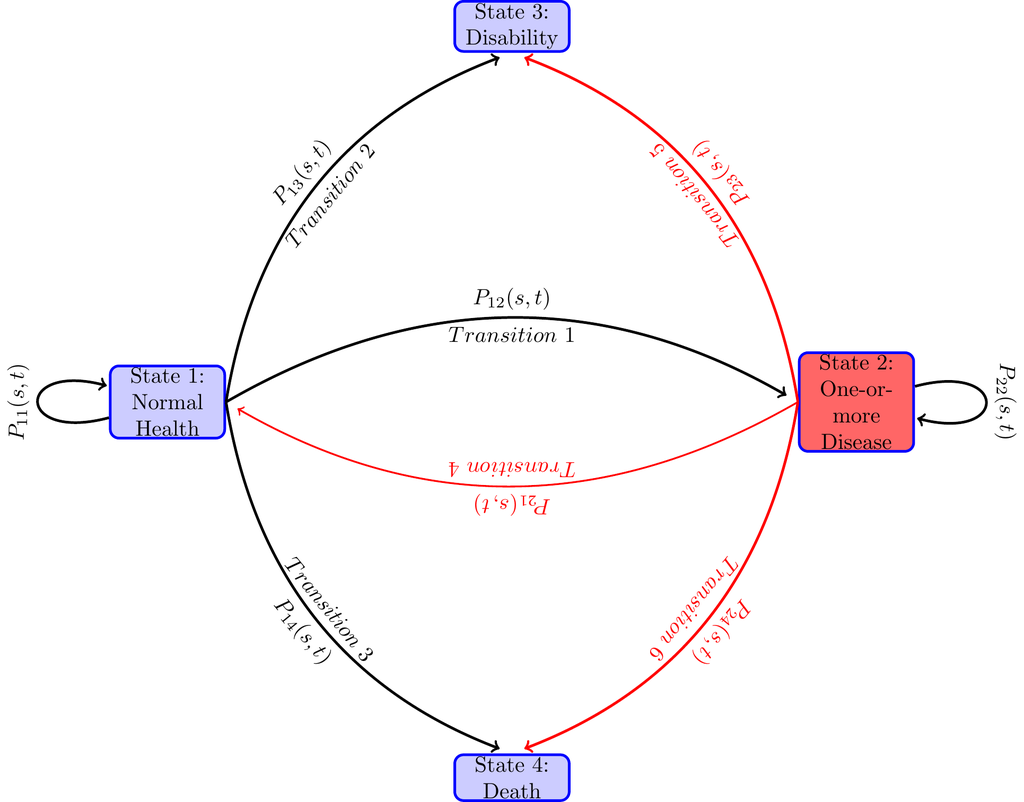

I model pathways through health states as a continuous-time finite-state stochastic process ${Z(t)},t \in T$, where at each time point $t$ during the study period $T$, the random variable $Z(t)$ takes a value from a finite set $S$ of health states. I take $T= [51,65]$. The state space $S$ of the stochastic process contains health states $1=$ “healthy or normal health”, $2=$ “diseased with one or more chronic diseases”, $3=$ “disabled with DI or SSI qualifying disability” and $4=$ “death”. Sometimes I will denote the state space as $S=\{h, i, d, D\}$ in place of $\{1,2,3,4\}$. Denote by $\mathcal{H}_t$ the history of a set of covariates $\{X(u), u \le t\}$ that are associated or are direct measures of genetic and epigenetic factors that influence the health development process up to time $t$, and $\{Z(u)u \le t\}$ the paths of health states that the individual has gone through up to time $t$. That is, $\mathcal{H}_t = \{Z(u),X(u)\}_{u=0}^t$. More generally, the history up to time $t$, is represented by a $\sigma$-algebra $\mathcal{F}_t$ which is generated by the history $\mathcal{H}_t$.

The transition probabilities of our stochastic process $Z(t)$ given the history process $\mathcal{H}_t$ are defined by,
$$P_{hj}(s,t;\mathcal{H}_s )=Prob(Z(t)=j \mid Z(s)=h, \mathcal{H}_s),
\tag{1}$$
for all $h,j\in S,$ $s,t\in T$, $t\geq s$. The transition probabilities contain important information about policy questions.

I use the counting process representation of the above event history process, which turns out to be very useful for modeling of event history data and for statistical inference of the model. For each individual corresponding to each transient health state $h$ ($h=1,2$), define two types of stochastic processes: (1) the counting processes $N_{hj}(t)$ denoting the **observed** number of transitions from health state $h$ to health state $j$ that the individual has made by time $t$. The vector $N(t)=(N_{hj}(t))$ is a multivariate counting process. (2) $Y_{h}(t)$, taking value $1$ if the individual is at risk at time $t$ for a transition from the transient health state $h$ to another feasible health state, and taking value $0$ otherwise.

The statistical modeling of the counting process data and its parameterization and statistical inference is generally performed with the *transition intensity functions*. I describe it now. Assume that the collection of information sets over time $\mathcal{F}=\{\mathcal{F}_t\}_{t\ge0}$, known as a *filtration*, is right continuous. Note that by construction, each component counting process $N_{hj}(t)$ is adapted to the filtration $\mathcal{F}$, meaning one can observe the value of the counting process at time $t$. The Doob-Meyer decomposition theorem asserts that the counting process can be uniquely decomposed into
$$N_{hj}(t) = A_{hj}(t)+ M_{hj}(t) \textit{ a.e., } \\
\text{i.e., data}=\text{model}+\text{error},$$
where $A_{hj}(t)$ is an increasing right-continuous predictable process, known as the *compensator* of the counting process and $M_{hj}(t)$ is a mean-zero martingale. Note that when it exists,
$$E\{dN_{hj}(t) \mid \mathcal{F}_t \} = \lambda_{hj}(t)dt,
\tag{2}$$

where $\lambda_{hj}(t)dt=dA_{ij}(t)$ is a function of the history up to time $t$, and is thus stochastic. I will denote this dependence as $\lambda _{hj}(t;\mathcal{H}_{t^-})$ The process $\lambda_{hj}(t)$ is known as the *transition intensity process* of the counting process $N_{hj}(t)$.

The transition intensity process Equation 2 is related to the notion of intensity function of the original finite state stochastic process $Z(t)$ by
$$\lambda _{hj}(t;\mathcal{H}_{t^-})=\lim_{\Delta t\downarrow 0}\frac{P(Z(t^- +\Delta t)=j \mid Z(t^{-})=h,\mathcal{H}_{t^-})}{\Delta t},\text{ for }
j\in S.$$
For the survival model (i.e., a two-state alive-dead model) with hazard function $\alpha(t)$, a deterministic function of $t$, it can be shown that $\lambda(t)=Y(t)\alpha(t)$. This type of intensity process is known as the *multiplicative intensity process*. In this paper I assume that each component of the multivariate counting process $N(t)$ has a multiplicative intensity process.

Denote the matrix of transition intensities by $\Gamma (t;{\mathcal H}_{t^-})=\left( \lambda_{ij}(t;{\mathcal H}(t^{-})\right)_{i,j=1,2,3,4}$ and the matrix of transition probabilities by $P\left( s,t;\mathcal{H}_s \right) \equiv \left( P_{hj}(s,t;\mathcal{H}_s)\right) _{h,j=1...4}$. For ease of presentation, I suppress the conditioning variable $\mathcal{H}_t)$.

Given that the stochastic health evolution process is parameterized for statistical inference in terms of transition intensities, it is important to know how to get the transition probabilities from the transition intensities? Under some mild assumptions on the transition intensity processes, this is accomplished using the notions of integrated transition intensity and product integration as follows:

For a transition $h\rightarrow j$, define the *integrated transition intensity* $\Lambda _{hj}(t)$ by $\Lambda _{hj}(t)\equiv \int_{0}^{t}\lambda _{hj}(u)du$ and the matrix function $\Lambda (t)=\left( \Lambda _{hj}(t)\right) _{h,j=1,2,3,4}$. Let a time interval $[s,t]$ be subdivided into a partition of $m$ sub-intervals with cut-off points $s=t_{0}<t_{1}<...<t_{m}=t$. It can be shown that
$$P(s,t)={\widetilde\prod}_{s\leq u\leq t}(I+d\Lambda (u))\overset{def}{\equiv
}
\lim_{\underset{\max t_{i}-t_{i-1} \rightarrow 0}
{\text{as }m\rightarrow \infty }
}
\prod \left(I+\Lambda (t_{i})-\Lambda (t_{i-1})\right) .
\tag{3}$$

The entity ${\widetilde\prod}_{s\leq u\leq t}(I+d\Lambda (u))$ defined above is known as the *product integral of the matrix function* $\Lambda (u)$.

The likelihood of the sample is given by,[^5]
$$\begin{split}
L\left( \theta \right) &=\prod\limits_{i}\prod\limits_{\underset{j\neq h}{(h,j)}:~ \underset{j=1,2,3,4}{h=1,2}}\left( \prod\limits_{t}\lambda
_{hj,i}\left( t \mid X_{h,i}(t)\right) ^{\Delta N_{hj,i}\left( t\right) }\right) \times \\
&\exp \left( -\int_{0}^{T_{h,i}^{\ast }}\lambda _{hj,i}\left(
u \mid X_{h,i}(u)\right) \right) du,
\end{split}
\tag{4}$$

where $T_{h,i}^{\ast}$ is the censor timing of individual $i$ in health state $h$, if any and treating $0^0=1$.

Parametric models specify distributions for $\lambda_{hj,i}(t)$’s in Equation 4 such as Weibull and Gamma. Even without covariates, close-form solution of the maximum likelihood parameter estimates for the Weibull model is difficult to obtain.

From the above, Andersen et al. (1993) derive the following generalized Cox partial likelihood function,
$$CL\left( \beta \right) =\prod\limits_{i}\prod\limits_{{h=1,2;\:}{{j=2,3,4;\:}{h\neq j}}}\prod\limits_{t}\left( \frac{
Y_{h,i}\left( t\right) \exp \left( \beta _{hj}^{\prime }X_{h,i}(t)\right) }{
\sum_{r}Y_{h,r}(t)\exp \left( \beta _{hj}^{\prime }X_{h,r}(t)\right) }\right)
^{\Delta N_{hj,i}\left( t\right) }
\tag{5}$$

Maximization of the generalized partial likelihood function Equation 5 produces consistent estimates of the regression parameters, known as *Cox partial likelihood estimates*. I will also follow this approach.

# 3 Econometric parameterization and Estimation

As mentioned in the introduction, the progression of health such as incidence of diseases, disabilities and mortality over life-course is determined by numerous factors. These factors include an individual’s genetic make-up, epigenetic configuration modulated by health behaviors and the surrounding environments, and their evolution over time, and the randomness generated by somatic mutations. Since this study focuses on disabilities that individuals apply for and then get entitlement onto a disability program, the incidence of such disabilities also depends on many economic factors that influence these decisions, such as the individual’s disability insured status, replacement rate and unemployment rate in the economy. The included covariates of a Cox regression model do not include many of those factors. Conditional on the included covariates, there remains individual variations in the risk of diseases, disability and mortality arising from the excluded factors. The variation in risks from excluded factors are known in the economics literature as the *unobserved heterogeneity* and in the epidemiology and statistical literature as *frailty*.

The transition intensity or hazard rate $\lambda_{hj}(t;X(t),V_{hj})$ of an event of transiting from health state $h$ to health state $j$ at time $t$ given the history $\mathcal{H}(t)=\{X(u),Z(u)\},0\le u \le t\}$ and unobserved heterogeneity level $V_{hj}$ is parameterized as follows,
$$\lambda _{hj}\left( t;X(t),V_{hj} \right) =\lambda _{hj}^{0}(t) V_{hj} e^{X(t)\beta _{hj} } =\lambda _{hj}^{0}(t) e^{X(t)\beta _{hj} + B_{hj} }.
\tag{6}$$
where $V_{hj}\equiv e^{B_{hj}}$. In the above specification, $\lambda _{hj}^{0}(t)$ is known as the *baseline hazard function*. The specification of transition intensity in Equation 6 is known as the *proportional hazard model*. It aggregates the effects of the regressors $X(t)$ linearly as $X(t)\beta _{hj}$, known as the *fixed effect* and shifts the baseline hazard function proportionately over time, by the factor $e^{X(t)\beta _{hj}}$. A regression coefficient $\beta$ of a covariate $X$ in the above specification quantifies the *individual treatment effect* in terms of the change in the risk (measured in log-scale) of encountering transition $h \to j$ at time $t$ from a unit increase in the treatment variable $X$. More specifically, let $h$ be the healthy state and $j$ be the disability health state and the treatment level $X=x_0$. The quantity $exp(\beta)$, known as the individual level *hazard ratio*, is the ratio of the probability of an individual from healthy state becoming disable at time $t$ if the treatment is increased by a unit $X=x_0+1$ over the individual’s probability of becoming disabled from healthy state at time $t$ with the treatment level $X=x_0$. Proportionality assumption implies that the individual hazard ratios are time constant. The variable $V_{hj}$ is the aggregate effect of all the unobserved covariates and it is assumed to be a random variable and hence known as the *random effect*. The interpretation of the frailty or unobserved heterogeneity variable $V_{hj}$ is that it imparts a random proportional shift of the baseline intensity by a multiplier of magnitude $v_{hj}$, which is the realized value of the random variable $V_{hj}$ for the individual. Individuals with higher realized values of $v_{hj}$ are more frail and will have higher probabilities of transition at any given age. For identification, it is assumed that $E(V_{hj})=1$. An individual with $V_{hj}=1$ will be referred to as the *average individual*.

The most widely used statistical procedure for estimation of the transition probabilities $P(s,t),$ $s,t\in T,s<t$ with or without covariates is to plug-in an estimate of $\Lambda (t;X(t))$ in Equation 3.

Assuming that there is no unobserved heterogeneity, there are broadly two types of statistical methods to get an estimate of $\Lambda (t;X(t))$ — parametric method and semi-parametric method. In the next Section 3.1, I will follow the widely used Aalen-Johnson-Fleming semi-parametric method. This method uses the Nelson-Aalen estimate of each component transition intensity function of $\Lambda (t;X(t))$ assuming a Cox proportional hazard model to incorporate the time-varying covariate effects. Note that without covariates, this semi-parametric method is, in fact, a nonparametric method. In Section 3.2, I address the problems associated with unobserved heterogeneity and how I correct for unobserved heterogeneity biases in our multi-state framework.

## 3.1 Aalen-Johansen-Fleming Estimator for Transition Probabilities

The bulk of developments of statistical methods for inference in the multi-state framework assumes the absence of unobserved heterogeneity. Two papers (Fleming 1978; and Aalen and Johansen 1978) independently extended the Kaplan-Meier nonparametric product limit estimator from survival analysis to the multi-state time to event models.[^6] I use this widely used estimation method as a baseline. I first describe the Aalen-Johansen-Fleming estimator for models with no covariates and then I describe the method for the general case with time-varying covariates, assuming the absence of unobserved heterogeneity. Section 3.2 describes the estimation procedure I follow to deal with unobserved heterogeneity.

For illustration, focus on one transition $h\rightarrow j$. Denote by $\bar{N} _{hj}(t)=\sum_{i}^{n}N_{hj,i}(t)$, a counting process measuring the number of transitions of the type $h\rightarrow j$ in the sample at time $t$, and by $\bar{Y} _{h}(t)=\sum_{i}^{n}Y_{h,i}(t)$, a counting process measuring the number of individuals in the sample at risk for a transition at time $t$. In any empirical study, data will be available only at discrete times, say in ordered times $0=t_{0}<t_{1}<...<t_{m}$. For a process $X(t)$ observed at these time points, denote by $\Delta X(t_i)=X(t_i) - X(t_{i-1})$ for $i>0$ and $\Delta X(t_0)=Z(t_0)$. At each observed time $t_{i}$ of the dataset, the procedure estimates each component transition intensity function by
$$\hat{\lambda}_{hj}(t_{i}) =\frac{\Delta \bar{N}_{hj} (t_{i}) }{\bar{Y}_{h}(t_{i}) },j \neq h .
\tag{7}$$

The *Nelson-Aalen non-parametric estimate* of the integrated transition intensity functions is given for each $h=1,2$ by
$$\begin{aligned}
\hat{\Lambda}_{hj}\left( t\right) &=\sum_{i:t_{i}\leq t}\hat{\lambda}
_{hj}\left( t_{i}\right) ,j\neq h, \\
\hat{\Lambda}_{hh}\left( t\right) &=-\sum \hat{\Lambda}_{hj}\left(
t\right) \text{ and} \\
\hat{\Lambda}_{hj}\left( t\right) &=0, \text{ for }h = 3,4;~~~j=1,2,3,4 .
\end{aligned}
\tag{8}$$

The *Aalen-Johansen-Fleming estimator* $\hat{P}(s,t)$, $s,t\in T,s<t$ for the transition probabilities is obtained by substituting for each component $hj$ the Nelson-Aalen estimates $\hat{\Lambda}_{hj}(t)$ and then applying the product integral formula Equation 3 as follows
$$\hat{P}( s,t) ={\widetilde\prod}_{s<u<t} (I+d\hat{\Lambda}(
u) ) = {\widetilde\prod}_{i:t_{i}\leq t} (I+\Delta \hat{\Lambda}
(t_{i}) ).
\tag{9}$$

With covariates, one obtains the Cox partial likelihood estimate $\hat\beta _{hj}$ separately for each transition $h\rightarrow j$ and then computes an weighted risk set defined by
$$\bar{Y}_{hj}^{\ast }(t)=\sum_{i=1}^{n}Y_{h,i}(t) \exp \left(
X_{(i)}(t)\hat{\beta}_{hj}\right),
\tag{10}$$
where $X_{(i)}$ denotes the vector of covariates of individual $i$.

The estimate of the intensity functions with covariates $\hat{\lambda}_{hj}(t_i;X)$ is obtained from Equation 7 by replacing, $\bar{Y}_{h}(t)$ with $\bar{Y}_{hj}^{\ast }(t)$ for each $h,j\in S$. This estimate of the intensity function is known as the *Breslow* estimate. The integrated hazard rates and the transition probabilities with regressors are estimated replicating the steps described in Equation 7 - Equation 9.

Aalen-Johnson-Fleming estimator has nice statistical properties. For instance, using Martingale calculus, it can be shown that the estimator is asymptotically unbiased and the normalized estimate is normally distributed (i.e., the central limit theorem holds for normalized parameter estimates) with an asymptotic estimable variance-covariance matrix (see for details, Aalen, Borgan, and Gjessing 2008; Andersen et al. 1993; Fleming and Harrington 2005; Wreede, Fiocco, and Putter 2010).

## 3.2 Unobserved Heterogeneity

Much of the research on unobserved heterogeneity is carried out for the two-state alive-death type models, i.e., in the notation of this paper, models with $S=\{1,2\}$, $1=$ alive, $2=$ death or $2=$ disability, treating it as an absorbing state. Very little is known for multi-state models, as these models are very difficult to handle analytically and numerically. Three types of statistical problems arise when unobserved heterogeneity is present. I discuss them in the following three subsections.

### 3.2.1 Biases in parameter estimates

In the presence of unobserved heterogeneity, the parameter estimates of the included covariates become asymptotically biased (Vaupel, Manton, and Stallard 1979; Heckman and Singer 1984a; Aalen et al. 2014). To correct for the unobserved heterogeneity bias in the two-state framework, a few studies incorporated unobserved heterogeneity in certain ways to estimate the parameters of fixed effects and random effects. I briefly describe the Ripatti and Palmgren (2000) method which I extend to the multi-state framework of this paper. In a two-state model, Ripatti and Palmgren (2000) assume the frailty specification to be as in the last equality of Equation 6. They assume that the frailty random variable $V$ is log-normally distributed with mean $1$ and variance $\theta$. They apply Laplace approximation to the marginal likelihood function[^7] of the sample. They decompose the approximated likelihood function into two components, one component allows one to apply the penalized Cox partial likelihood procedure to estimate $\beta$’s, $b$’s and their standard errors, given $\theta$ fixed, and using the other component, they estimate $\theta$ and its standard errors given the estimated $\beta$’s and $b$’s fixed. They alternate the two-steps iteration steps until convergence. One fallout of their estimation procedure is that the estimated standard errors of the $\beta$’s and $b$’s are underestimated as the penalized partial likelihood for estimating those parameters and their standard errors treats the value of $\theta$ fixed. In their simulation exercise, they showed that the biases are small. This estimation procedure is implemented in the R package `coxme` by Therneau (2022). The package also provides a $\chi^2$ statistic to test the null hypothesis $H_0: \theta=0$.[^8]

In the multi-state framework, one has a vector of frailties $B=(B_{hj},h,j \in S,j \ne h)$, each component corresponds to a transition. No estimation procedures are available for general distribution of $B$. As a first step, I consider two types of frailty distributions that enable one to apply the Ripatti and Palmgren (2000) technique and the Therneau (2022) `coxme` package to get parameter estimates for the multi-state model. In one specification, I assume that the frailty random effects are independent across transitions. This allows one to apply the Ripatti and Palmgren (2000) technique to each transition separately. These parameter estimates together with the $\chi^2$ test statistics for each transition are reported in Table 4 and Table 5. I found that the parameter estimates are all slightly higher in magnitude compared to the parameter estimates of the Cox models without including unobserved heterogeneity term. In the second specification, I assume that the random effects across transitions are identical, i.e., a common or shared random effect across all transitions for each individual. These parameter estimates are used for the policy analysis of section Section 7 and the estimates of the fixed effects and the $\chi^2$ statistic to test if the common frailty has variance $0$ are reported in Table 8. Again, I found that the estimates for $\beta$’s have slightly higher magnitude than the Cox partial likelihood estimates without unobserved heterogeneity (not reported).

### 3.2.2 Dynamic selection and mixed transition intensity and transition probabilities

The second problem with unobserved heterogeneity is that the estimates of transition intensities and transition probabilities, computed even with the bias corrected regression coefficients of the covariates in Equation 7 - Equation 10, are for an average individual, i.e., for an individual with frailty level equals the population average frailty level. They will give biased estimates of the population average of individual effects because of the dynamic selection problem. The higher is the variance of the random effect, the higher is the bias. I explain it with the above two-state model. Let the Laplace transform of the frailty random variable $V_{12}$ be denoted as $\mathcal{L}_{12}(c)\overset{def}{=}\int_0^\infty e^{-cv}dG_{12}(v;\theta)$, where $G_{12}(v;\theta)$ is the distribution function of $V_{12}$.[^9] I use the superscript $m$ on an entity to represent the entity’s marginal distribution or the population average. Note that the survival function of an individual with unobserved heterogeneity or frailty level $V_{12}=v$ is given by $P_{11}(t;X,v)=exp(-v\Lambda_{12}(t;X))$. The population survival function is a mixture of the individual survival functions and is given by
$$P^m_{11}(t;X) \equiv \int_0^\infty exp(-v\Lambda_{12}(t;X)) dG_{12}(v;\theta)
={\mathcal{L}}_{12}(\Lambda_{12}(t;X))
\tag{11}$$

The population-average transition intensity is given by
$$\begin{aligned}
\lambda_{12}^m(t;X) &\equiv -d ln P_{11}^m(t;X) / dt
= - \lambda_{12}(t;X) \frac{{\mathcal L}_{12}^{\prime}(\Lambda_{12}(t;X))}{{\mathcal L}_{12}(\Lambda_{12}(t;X))} \\
&= \lambda_{12}(t;X)\int_0^\infty v dG_{12}(v \mid X, T\ge t;\theta)
\end{aligned}
\tag{12}$$

An individual with higher frailty level will have higher probability of encountering a transition. As time progresses, the transition free population of given characteristics $X$ consists of higher proportion of individuals of lower frailties as compared to an earlier time. This is what is meant by *dynamic selection*. This dynamic selection will make the average frailty level of the transition-free population over time — i.e., the value of the integral in the second line of Equation 12 — become smaller and smaller, except at $t=0$ when they are equal. A fallout of this is that the proportionality assumption of the individual intensity functions will not hold for the population-average intensity function. As a result, an estimated regression coefficient of a covariate will give biased estimate of its hazard ratio or the average treatment effect at the population level. Another fallout of the dynamic selection is that the average of the individual transition probabilities of a population $P_{12}^m(t;X)$ will be smaller and smaller over time than the transition probability of the average individual, $P_{12}(t;X,V_{12}=1)$. Furthermore, the higher the variance $\theta$ of $V_{12}$, the smaller becomes $P_{12}^m(t;X)$ for all time $t>0$. When the frailty variance $\theta \to 0$, the average transition probability $P_{12}^m(t;X) \to$ $P_{12}(t;X, V_{12}=1)$, the transition probability of the average individual. Figure 2 illustrates the above for the case of a constant baseline hazard function without covariates for the gamma frailty distribution with two values of $\theta$.

Figure 2: Comparing the probability of a transition for an individual with average frailty level, $P_{12}(t \vert V=1)$, with population average $P_{12}^m(t)$ for $\lambda=.04$, and $\theta=0.492$, $\theta_{1}=0.8$

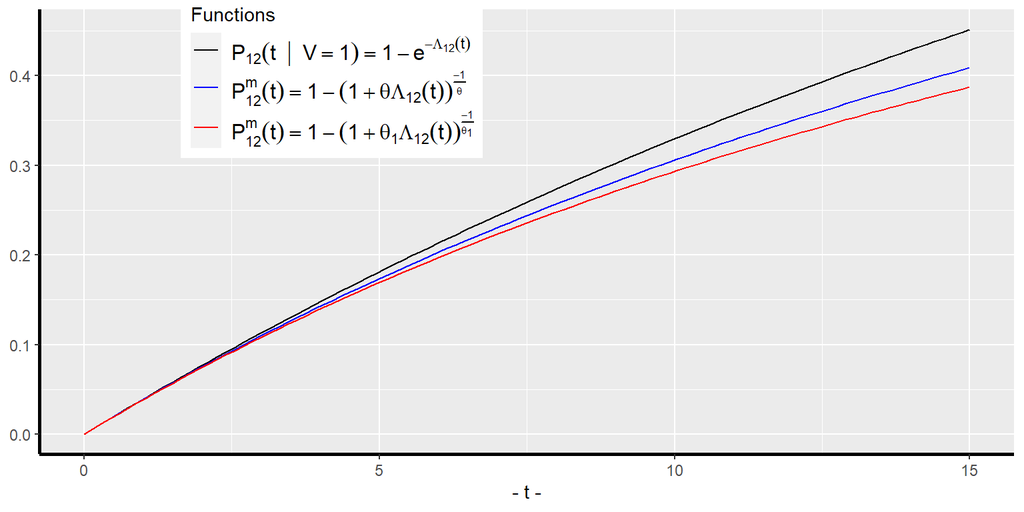

For general multi-state models such as ours, no tractable numerical algorithms are currently available to compute the population-averages of transition intensities or transition probabilities. In the policy analysis of Section 7, I will use the transition intensities and transition probabilities of the average individual, i.e., the individual with all $V_{hj}=1$ to study treatment effects of policies.

### 3.2.3 Identification problems

The third problem created by unobserved heterogeneity is the identification problem. To see it, assume that there no covariates. Equation 12 becomes $\lambda_{12}^m(t)=\lambda_{12}^0(t) \cdot g(t)$, where $g(t)=\Lambda_{12}'(t)/\Lambda_{12}(t)$, a function of $t$. From a random sample one can only estimate $\lambda_{12}^m(t)$, which is consistent with both a specification of individual intensities $\lambda_{12}^0(t)$ together with frailty (whose distribution yields the term $g(t))$ and a specification without frailty, i.e., taking the baseline hazard in Equation 6 as $\lambda_{12}^m(t)$ and $V=1$. It is clear that unobserved heterogeneity cannot be identified without having further structure. Elbers and Ridder (1982) were the first to show this identification problem. They also showed that identification can be achieved when there are covariates in the proportional hazard specification and the unobserved heterogeneity has finite mean (see also Heckman and Singer (1983) and Heckman and Singer (1984b) for other identification conditions in proportional hazard specifications).

An important point to note is that a non-parametric estimate of the transition intensity in models without covariates already encompasses the effect of unobserved heterogeneity if there is any.  
Thus, the non-parametric estimates I present below in Section 4.2 are free from unobserved heterogeneity biases.

For general multi-state models such as ours, no tractable numerical algorithms are currently available to compute the population-averages of transition intensities or transition probabilities of individuals. In the policy analysis of Section 7, I will use the transition intensities and transition probabilities of an individual with all $V_{hj}=1$ to study treatment effects of policies.

# 4 The dataset and the variables

I use the Health and Retirement Study (HRS) dataset for empirical analysis. A lot has been reported on the family of HRS datasets—about its structure, purpose, and various modules collecting data on genetics, biomarkers, cognitive functioning, and more, see for instance (Juster and Suzman 1995; Sonnega et al. 2014; Fisher and Ryan 2017). The first survey was conducted in 1992 on a representative sample of individuals living in households i.e., in non-institutionalized, community dwelling in the United States from the population of cohorts born during 1931 to 1941 and their spouses of any age. “The sample was drawn at the household financial unit level using a multistage, national area-clustered probability sample frame. An oversampling of Blacks, Hispanics (primarily Mexican Americans), and Florida residents were drawn to increase the sample size of Blacks and Hispanics as well as those who reside in the state of Florida” (Fisher and Ryan 2017). The number of respondents were 13,593. Since 1992, the survey was repeated every two years. In each wave of new surveys in 1993, 1998, 2004 and 2010, new cohorts were added, ending the survey up with a sample size of 37,495 from around 23,000 households in wave 12 in 2014. RAND created many variables from the original HRS data for ease of use. I create all the variables for the paper (with a few exceptions mentioned below) from the RAND HRS Longitudinal File 2016 (V2) dataset. The details of the Rand HRS dataset can be found in Bugliari et al. (2016).

As mentioned in the introduction, I define the disability health state to be one that qualifies one to be on the disability programs OASDI or SSI. The data on disability is self-reported. Later I plan to use the Social Security Administration’s matched administrative data with actual disability entitlement information. The matched data will, however, reduce the sample size to half, as only 50 percent of the respondents are used for matching HRS with SSA Administrative data. The HRS dataset collected information on if and when the doctor diagnosed that the respondent has any of the severe diseases such as high blood pressure, diabetes, cancer, lung disease, heart attack, stroke, psychiatric disorder and severe arthritis. I drop respondents who received disability before the first survey year and I also drop the spouses in the sample who were not between ages 51 to 61 and were disabled or dead before or in the survey year.

Table 1 provides a few characteristics of the data.

Table 1: Summary of the health status of the individuals in the sample over the survey years.

| Survey Year | Alive:normal health | Alive: diseased | Became disabled | Died | Attained FRA | Total |
| --- | --- | --- | --- | --- | --- | --- |
| 1992 | 3,027 | 6,442 | 92 | 0 | 0 | 9,561 |
| 1994 | 2,603 | 6,645 | 77 | 144 | 0 | 9,469 |
| 1996 | 2,299 | 6,661 | 140 | 148 | 0 | 9,248 |
| 1998 | 2,483 | 6,642 | 134 | 123 | 736 | 10,118 |
| 2000 | 1,944 | 5,529 | 99 | 128 | 747 | 8,447 |
| 2002 | 1,388 | 4,440 | 82 | 75 | 760 | 6,745 |
| 2004 | 2,084 | 5,489 | 63 | 66 | 785 | 8,487 |
| 2006 | 1,532 | 4,356 | 46 | 61 | 798 | 6,793 |
| 2008 | 1,183 | 3,621 | 53 | 42 | 220 | 5,119 |
| 2010 | 2,133 | 5,728 | 52 | 49 | 265 | 8,227 |
| 2012 | 1,818 | 5,283 | 107 | 67 | 331 | 7,606 |
| 2014 | 1,475 | 4,704 | 94 | 87 | 412 | 6,772 |
| 2016 | 2,338 | 6,035 | 58 | 58 | 499 | 8,988 |

## 4.1 Variables

I have noted earlier the importance of early childhood factors such as childhood socioeconomic status, childhood health status, cognitive and non-cognitive skills in determining the health developments in the middle ages. Other important factors are biomarkers, measuring the initial physical and mental health status, and health related behaviors in middle ages. Furthermore, the health development may vary by race and sex. I describe the construction of the relevant variables in this subsection.

The demographic variables **White** and **Female** have the standard definitions. Education level is categorized into 3 levels, **less than High School**, **High School and Some College**, and **College+** i.e., completed college degree or higher.

**Total Cognitive Scores:** This variable is a measure of cognitive functioning. RAND combined the original HRS scores on cognitive function measure which includes “immediate and delayed word recall, the serial 7s test, counting backwards, naming tasks (e.g., date-naming), and vocabulary questions’’. Three of the original HRS cognition summary indices—two indices of scores on 20 and 40 words recalls and a third index is a score on the mental status index which is sum of scores”from counting, naming, and vocabulary tasks”—are added together to create this variable. Again, due to non-compatibility with the rest of the waves, the score in the first wave was not reported in the RAND HRS. I have imputed it by taking the first future non-missing value of this variable.

**BMI:** The variable body-mass-index (BMI) is the standard measure used in the medical field and HRS collected data on this for all individuals. If it is missing in 1992, I have imputed it with the first future non-missing value for the variable. Following the criterion in the literature, I categorized BMI into four levels: **underweight** if BMI < 18.5, **normal weight** if $18.5 \ge$ BMI < 25, **overweight** if $25 \ge$ BMI < 30, and **obese** if BMI $\ge$ 30, taking normal weight as the reference level. In some models, I use a dummy variable **High BMI** which takes value $1$ if BMI $\ge 25$.

Now I describe the construction of the behavioral variables.

**Behavior: Smoking:** This variable is constructed to be a binary variable taking value 1 if the respondent has reported yes to ever smoked question during any of the waves as reported in the RAND HRS data and then repeated the value for all the years.

**Behavior: Exercising:** The RAND HRS has data on whether the respondent did vigorous exercise three or more days per week. This variable takes value 1 if the respondent did vigorous exercise three or more days per week in any of the waves, otherwise it takes value 0. The values are repeated for all the years.

I have used a two parameter IRT model (which includes the well-known Rasch model as a special case) from the latent variable analysis literature to construct an aggregate measure of childhood socioeconomic status, **Childhood SES** in SAS. See Cai et al. (2016) for a survey of IRT models of multi-dimensional traits and extensions to dynamic scoring, and An and Yung (2014) for details on the SAS IRT procedure and general introduction to various IRT procedures that SAS can perform.

**Childhood SES:** This variable is a binary variable measuring childhood SES. I constructed it using the IRT procedure as follows. From the HRS data I created four binary variables using the original categorical data on whether family moved for financial reason, family usually got financial help during childhood, father unemployed during childhood, father’s usual occupation during childhood. For each variable, I assigned 0, if it is disadvantageous and 1 if it is advantageous; three tertiary variables two on each parent’s education levels assigning 0 = High School dropout, 1 = some college, 2 = completed college and higher and the third on family financial situation (0 = poor, 1 = average, 2 = well-off). I used these seven variables as items in the IRT procedure to first compute a continuous score estimate and then I define **Childhood SES** = 1 if the score is above mean plus one standard deviation of the scores and 0 otherwise.

**Childhood Health** is a binary measure of childhood health constructed from the self-reported qualitative childhood health variable in HRS. I define **Childhood Health** = 1 if the respondent reported very good or excellent health, and zero otherwise.

**Init.HLTH** is a categorical variable denoting the initial health state of an respondent right before the respondent entered the Health and Retirement Study. It takes value $1$, if the respondent was in normal health and value $2$ if the respondent had one-or-more serious diseases.

## 4.2 Time varying transition intensities without covariates

Figure 3 panel(a) shows the probabilities of a representative individual of age 51 to remain in normal health, contact one-or-more diseases, become disabled or die as the years pass by. Similarly, Figure 3 panel(b) shows the corresponding probabilities for an individual of age 51 who is in the health state of one-or more diseases.

Figure 3: Transition probabilities (a) from normal health state and (b)from one-or-more diseased health state

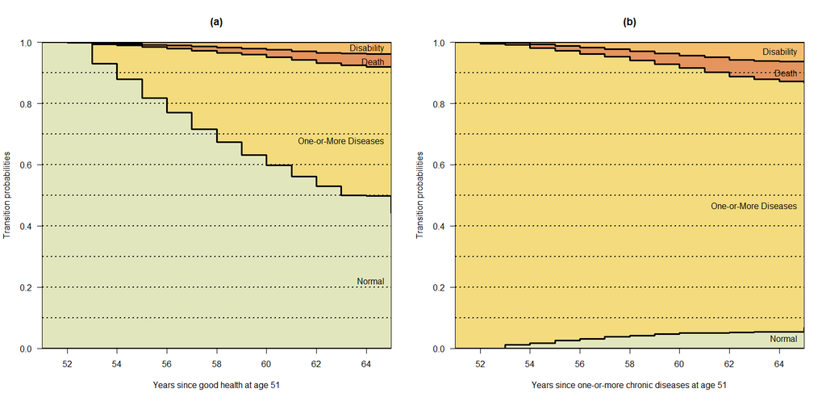

Table 2: Transition probabilities for transition $i \to j$ by duration of stay in state 1 and 2 from the semi-parametric multistate model.

| Duration | 1 → 1 | 2 → 2 | 1 → 2 | 2 → 1 | 1 → 3 | 2 → 3 | 1 → 4 | 2 → 4 |
| --- | --- | --- | --- | --- | --- | --- | --- | --- |
| 51 | 1.0000 | 1.0000 | 0.0000 | 0.0000 | 0.0000 | 0.0000 | 0.0000 | 0.0000 |
| 52 | 0.9946 | 0.9895 | 0.0000 | 0.0000 | 0.0000 | 0.0000 | 0.0054 | 0.0105 |
| 53 | 0.8982 | 0.9736 | 0.0857 | 0.0124 | 0.0054 | 0.0000 | 0.0108 | 0.0141 |
| 54 | 0.8414 | 0.9550 | 0.1360 | 0.0165 | 0.0095 | 0.0072 | 0.0132 | 0.0213 |
| 55 | 0.7665 | 0.9254 | 0.2031 | 0.0325 | 0.0124 | 0.0144 | 0.0180 | 0.0277 |
| 56 | 0.7074 | 0.9029 | 0.2523 | 0.0418 | 0.0183 | 0.0204 | 0.0221 | 0.0348 |
| 57 | 0.6391 | 0.8800 | 0.3101 | 0.0510 | 0.0227 | 0.0275 | 0.0280 | 0.0415 |
| 58 | 0.5861 | 0.8569 | 0.3503 | 0.0558 | 0.0300 | 0.0375 | 0.0337 | 0.0498 |
| 59 | 0.5326 | 0.8331 | 0.3935 | 0.0644 | 0.0354 | 0.0458 | 0.0385 | 0.0567 |
| 60 | 0.4931 | 0.8106 | 0.4213 | 0.0694 | 0.0412 | 0.0545 | 0.0444 | 0.0655 |
| 61 | 0.4455 | 0.7921 | 0.4540 | 0.0696 | 0.0478 | 0.0617 | 0.0528 | 0.0766 |
| 62 | 0.4033 | 0.7727 | 0.4792 | 0.0689 | 0.0572 | 0.0722 | 0.0603 | 0.0861 |
| 63 | 0.3648 | 0.7581 | 0.5069 | 0.0702 | 0.0614 | 0.0773 | 0.0669 | 0.0944 |
| 64 | 0.3626 | 0.7471 | 0.4995 | 0.0698 | 0.0639 | 0.0801 | 0.0740 | 0.1030 |
| 65 | 0.3071 | 0.7381 | 0.5496 | 0.0718 | 0.0648 | 0.0815 | 0.0785 | 0.1086 |

# 5 Childhood factors, health behaviors and mid-age health outcomes

As mentioned in the introduction, the molecular biology literature points out that stressors of the body cells are important factors during early development and later life health progression.[^10] While cellular level stressors during early cell developments cannot be directly observed or measured, many socioeconomic factors that modulate the cell level stressors can be observed. Those early-life socioeconomic factors thus maybe be associated with early-life health outcomes. Furthermore, early-life health developments together with later-life health behaviors determine later-life health outcomes. Health behaviors are also partly determined by cognitive abilities. Education level, an indicator of cognitive ability, can thus affect health behaviors and health developments in later life. Education is also an important determinant of earnings, which affect health related expenditures and thus health outcomes.

The HRS dataset does not have prenatal or postnatal data on individuals. It has a few variables on childhood socioeconomic status, which are correlates of the stressors of cell developments. How does one quantify childhood SES (denoted as cSES now on)? There is no consensus on what exactly constitutes cSES. Some studies use different sets of variables to represent cSES. For instance, Heckman and Raut (2016) and a few other studies used parents’ education as a measure of childhood SES in modeling the attainment of college degree. Luo and Waite (2005) used Father’s and Mother’s education and the Family financial well-being as regressors without aggregating them into a single measure to examine how these variables affect middle age health outcomes for the HRS sample. It is, however, useful to have a single measure of cSES. Some studies used the latent variable approach to come up with a statistically defined measure of cSES. For instance, Vable et al. (2017) used the Mplus software to create their latent variable measure of cSES using a number of childhood variables from the HRS dataset. I have used a slightly different latent variable statistical procedure, namely IRT, on a set of parental characteristics during the childhood of the respondents. I use this variable and a few other variables in the Logistic regression models of the childhood factors described below.

Childhood health status (cHLTH) is an important factor for later life health outcomes and educational attainments. The cSES variable influences the stressors of the cells’ environment and thus will affect cHLTH. Apart from cSES, other factors such as nutrition and pediatric health care are also important factors. We do not have data on those variables. In the next subsection I will specify a Logit model of cHLTH with childhood socioeconomic status and other observable characteristics as regressors.

Cognitive skill or Education level is an important factor for later life health outcomes as it determines various health related choices an individual makes throughout life. It is also an important determinant of earnings, and employment with or without covered health insurance. Similar to many studies, I use a binary education level, College+. Many factors — such as innate IQ, family background, preschool inputs, prenatal and postnatal stressors for brain development, the childhood health status, and mother’s time input — determine the College+ variable. See, Heckman (2008) and Raut (2018) for recent literature on the biology of brain development and the roles played by socioeconomic factors, and Heckman and Raut (2016) for a Logit model of College+ in which a measure of IQ, family background measured with parents’ education, preschool inputs and non-cognitive skills play important roles. HRS does not have data on many such variables. I use cSES and cHLTH, together with a few other demographic variables as regressors in the Logistic regression specifications College+ in the next subsection.

I examine two types of middle age health outcomes: (1) initial health status, Init.HLTH, of the respondents in their early *50s* when they first participated in the HRS study; and (2) pathways through the health states that they traversed starting from the initial health state. Both types of health outcomes are modeled as functions of childhood factors, cSES, cHLTH and College+.

## 5.1 Models of childhood socioeconomic status, childhood health and initial middle age health

Table 3: Effects of childhood factors, race and sex on childhood health, college education and initial health in early 50s.

|  | Childhood Health |  | College+ |  | Init.HLTH |  |
| --- | --- | --- | --- | --- | --- | --- |
|  | (1) | (2) | (1) | (2) | (1) | (2) |
| Intercept | 0.774 *** | -0.386 *** | 0.211 *** | 0.093 | -1.101 *** | -1.126 *** |
|  | (0.032) | (0.044) | (0.041) | (0.051) | (0.070) | (0.077) |
| White | 0.131 *** | 0.067 * | 0.552 *** | 0.441 *** | 0.201 *** | 0.189 ** |
|  | (0.032) | (0.033) | (0.035) | (0.036) | (0.057) | (0.058) |
| Female | -0.087 ** | -0.097 ** | 0.020 | 0.070 * | -0.218 *** | -0.218 *** |
|  | (0.030) | (0.031) | (0.034) | (0.035) | (0.044) | (0.044) |
| childhood SES | 0.725 *** |  | 1.667 *** |  | 0.204 *** |  |
|  | (0.036) |  | (0.056) |  | (0.056) |  |
| Father High School |  | 0.293 *** |  | 0.962 *** |  | 0.076 |
| or some college |  | (0.043) |  | (0.060) |  | (0.062) |
| Father college+ |  | 0.148 * |  | 1.829 *** |  | 0.186 |
|  |  | (0.075) |  | (0.174) |  | (0.111) |
| Mother High School |  | 0.466 *** |  | 1.306 *** |  | 0.132 * |
| or some college |  | (0.039) |  | (0.052) |  | (0.059) |
| Mother college+ |  | 0.427 *** |  | 2.083 *** |  | 0.143 |
|  |  | (0.079) |  | (0.188) |  | (0.127) |
| Family moved due to |  | 0.634 *** |  | 0.164 *** |  | 0.035 |
| financial difficulties |  | (0.040) |  | (0.048) |  | (0.066) |
| Father unemployed |  | 0.373 *** |  | 0.108 ** |  | 0.024 |
| during childhood |  | (0.036) |  | (0.042) |  | (0.056) |
| Family got financial |  | 0.533 *** |  | -0.419 *** |  | 0.005 |
| help in childhood |  | (0.041) |  | (0.052) |  | (0.070) |
| Father's Occupation |  | 0.132 * |  | 0.289 *** |  | -0.001 |
|  |  | (0.053) |  | (0.070) |  | (0.080) |
| Childhood Health |  |  | 0.732 *** | 0.634 *** | 0.203 *** | 0.173 *** |
|  |  |  | (0.035) | (0.038) | (0.048) | (0.052) |
| High School or |  |  |  |  | 0.170 ** | 0.148 ** |
| some college |  |  |  |  | (0.055) | (0.056) |
| College+ |  |  |  |  | 0.278 *** | 0.237 ** |
|  |  |  |  |  | (0.072) | (0.075) |
| N | 24052 | 24052 | 24052 | 24052 | 9561 | 9561 |
| logLik | -13711.11 | -12882.41 | -10808.90 | -10013.18 | -5975.83 | -5972.50 |
| AIC | 27430.22 | 25786.82 | 21627.81 | 20050.36 | 11965.66 | 11973.00 |
| Pseudo R-squared | 0.018 | 0.077 | 0.094 | 0.161 | 0.010 | 0.011 |
| Notes: *** p < 0.001; ** p < 0.01; * p < 0.05. Standard errors are in parenthesis. |  |  |  |  |  |  |

From the statistically significant parameter estimates of the variable cSES in the models with cSES as a regressor, we see that cSES has positive effect on childhood health, and on the probability of attaining College+ education and on the probability of possessing normal health state as opposed to diseased health state up to one’s early *50s*.

The estimated College+ and Init.Health models show that a better childhood health leads to a higher probability of College+ education and a higher probability of being in normal health in one’s early *50s*. A College+ education also has a significant positive effect on the probability of possessing normal health in one’s early *50s*.

It is possible that even after controlling for cSES, cHLTH and College+, the race and gender variables might be picking up the effects of health behaviors. I cannot control for health behaviors in the models of this subsection as the HRS data does not have data on health behaviors prior to the survey years. In the next two subsections, I will examine the effects of race and gender variables, controlling for the effects of childhood factors, biomarkers, and health behaviors on the health developments through middle ages, more specifically on probabilities of following different health trajectories starting at age *51*.

## 5.2 Childhood factors and middle age health pathways

I examine the effect of childhood factors, race and sex on the probabilities of various health pathways. The parameter estimates are shown in Table 4.

Table 4: Unobserved heterogeneity bias corrected estimates of Cox regression models with childhood factors as regressors.

|  | 1 → 2 | 1 → 3 | 1 → 4 | 2 → 1 | 2 → 3 | 2 → 4 |
| --- | --- | --- | --- | --- | --- | --- |
| White | 0.436 *** | 0.362 | -0.275 | 0.422 *** | 0.052 | 0.139 |
|  | (0.040) | (0.201) | (0.172) | (0.065) | (0.072) | (0.072) |
| Female | 0.036 | -0.337 | -0.386 * | -0.246 *** | -0.049 | -0.543 *** |
|  | (0.033) | (0.178) | (0.171) | (0.056) | (0.068) | (0.067) |
| Childhood SES | -0.332 *** | -0.410 | -0.607 ** | -0.092 | -0.281 ** | -0.499 *** |
|  | (0.038) | (0.215) | (0.226) | (0.064) | (0.087) | (0.091) |
| Childhood Health | 0.036 | -0.266 | -1.745 *** | 0.119 | 0.048 | -1.161 *** |
|  | (0.041) | (0.193) | (0.174) | (0.066) | (0.076) | (0.068) |
| High School or some college | -0.164 ** | -0.272 | 0.150 | -0.146 | -0.407 *** | -0.157 |
|  | (0.046) | (0.210) | (0.200) | (0.076) | (0.079) | (0.079) |
| College+ | -0.249 *** | -1.434 *** | -0.672 * | -0.020 | -1.259 *** | -0.454 *** |
|  | (0.055) | (0.343) | (0.314) | (0.091) | (0.134) | (0.116) |
| #obs | 8051 | 8051 | 8051 | 17625 | 17625 | 17625 |
| #events | 3693 | 135 | 148 | 1294 | 870 | 912 |
| θ | 0.4907 | 0.4296 | 1.0329 | 0.6568 | 0.0004 | 0.9025 |
| χ² | 363.427 | 0.508 | 2.465 | 33.069 | 6.520 | 20.025 |
| χ²-pvalue | 0.000 | 0.476 | 0.116 | 0.000 | 0.011 | 0.000 |
| R² | 0.208 | 0.013 | 0.037 | 0.051 | 0.008 | 0.068 |
| Notes: *** p < 0.001; ** p < 0.01; * p < 0.05. Standard errors are in parenthesis. The statistic χ² is for testing the null hypothesis, H₀: θ = 0, i.e., no unobserved heterogeneity and χ²-pvalue is it… |  |  |  |  |  |  |

To understand the quantitative significance of the Cox regression parameter estimates, consider the parameter estimate of -1.745 for the variable Childhood Health and event $1 \to 4$ in Table 4. This says that an individual of a given age in normal health status who had normal health status in childhood will have a $0.175 \equiv exp(-1.745)$ times lower risk of death. The quantity $exp(\beta)$ for a variable with coefficient $\beta$, is known as the *hazard ratio* of the variable. The effects of other parameters can be easily seen from the table.

From Table 4, the estimated hazard ratio for the College+ variable for transition $1 \to 3$ is 0.238 $(\equiv exp(-1.434))$, which means that the probability of a college graduate of normal health at age $51$ becoming disabled at any age is 0.238 times the probability of a person of normal health at age $51$ without a college degree becoming disabled at that age. In Cox proportional hazard models, the hazard ratio is time constant, i.e., this ratio is same at all ages.

From the estimates in Table 4, it is clear that childhood health has the most significant effect for transition $1 \to 4$ with a proportional hazard ratio of 0.17 $\equiv exp$(-1.745), i.e., the probability of dying of an individual in normal health at age $51$ and normal childhood health is 0.17 times the probability (s)he would have had, had (s)he had bad childhood health. A better childhood health leads to a lower probability of death and a higher probability of recovering from diseased health state. A better childhood health also has a higher probability of becoming diseased, but given that a better childhood health also leads to a higher probability of recovery from diseased health state, comparing the magnitudes of the parameter estimates for transitions $1 \to 2$ and $2 \to 1$, we see that a better childhood health leads to a lower net transition from $1 \to 2$.

An individual from disadvantaged SES during childhood has a higher probability of disease incidence and a higher probability ofdeath after they become diseased.

As far as getting onto the disability rolls, the only variable that has a significant effect is College+.

## 5.3 Childhood factors, health behaviors, and middle age health pathways

For the Cox regression parameter estimates, I have used both the R package *mstate* (see, Wreede, Fiocco, and Putter (2010) for details) and also used the SAS procedure *phreg* (both produced the same estimates) and used the *mstate* package to estimate all the transition probabilities (SAS does not have readily available procedure for this purpose). The parameter estimates are shown in Table 5.

Table 5: Unobserved heterogeneity bias corrected estimates of Cox regression models with childhood factors, biomarkers, and health behaviors.

|  | 1 → 2 | 1 → 3 | 1 → 4 | 2 → 1 | 2 → 3 | 2 → 4 |
| --- | --- | --- | --- | --- | --- | --- |
| White | 0.226 *** | 0.438 * | -0.462 | 0.134 | -0.029 | -0.007 |
|  | (0.043) | (0.218) | (0.248) | (0.070) | (0.077) | (0.093) |
| Female | 0.094 * | -0.193 | -0.428 | -0.267 *** | -0.098 | -0.415 *** |
|  | (0.035) | (0.194) | (0.252) | (0.060) | (0.072) | (0.086) |
| Childhood SES | -0.199 *** | -0.204 | 0.087 | -0.039 | -0.192 * | -0.091 |
|  | (0.039) | (0.226) | (0.274) | (0.066) | (0.089) | (0.100) |
| Childhood Health | -0.141 ** | -0.143 | -0.898 *** | 0.007 | 0.020 | -0.416 *** |
|  | (0.043) | (0.214) | (0.243) | (0.069) | (0.078) | (0.088) |
| High School or some college | -0.118 * | 0.153 | -0.066 | -0.140 | -0.257 ** | 0.044 |
|  | (0.050) | (0.237) | (0.297) | (0.083) | (0.085) | (0.109) |
| College+ | -0.142 * | -0.633 | -0.816 | -0.075 | -0.994 *** | -0.217 |
|  | (0.062) | (0.389) | (0.472) | (0.103) | (0.145) | (0.157) |
| CES-D | 0.531 *** | 1.614 *** | 0.129 | -0.484 *** | 0.969 *** | 0.568 *** |
|  | (0.084) | (0.334) | (0.521) | (0.133) | (0.117) | (0.146) |
| Total cognitive scores | 0.009 | -0.088 *** | -0.027 | 0.002 | -0.002 | -0.003 |
|  | (0.004) | (0.021) | (0.028) | (0.007) | (0.008) | (0.010) |
| BMI: Underweight | -0.398 | -0.167 | 1.898 *** | -0.139 | 0.038 | 0.830 ** |
|  | (0.221) | (1.016) | (0.549) | (0.321) | (0.361) | (0.290) |
| BMI: Overweight | 0.187 *** | -0.052 | -0.096 | -0.307 *** | -0.199 * | -0.189 |
|  | (0.039) | (0.211) | (0.275) | (0.067) | (0.093) | (0.105) |
| BMI: Obese | 0.439 *** | 0.237 | 0.213 | -0.768 *** | 0.075 | -0.263 * |
|  | (0.047) | (0.241) | (0.307) | (0.079) | (0.089) | (0.108) |
| Behavior: Smoking | 0.137 *** | 0.615 ** | 1.231 *** | -0.057 | 0.349 *** | 0.626 *** |
|  | (0.035) | (0.207) | (0.310) | (0.060) | (0.077) | (0.098) |
| Behavior: Exercising | 0.167 *** | -0.182 | -0.985 *** | 0.333 *** | -0.309 *** | -0.904 *** |
|  | (0.043) | (0.206) | (0.234) | (0.071) | (0.073) | (0.086) |
| #obs | 6438 | 6438 | 6438 | 14170 | 14170 | 14170 |
| #events | 3514 | 123 | 77 | 1228 | 841 | 592 |
| θ | 0.3030 | 0.7767 | 0.3857 | 0.4998 | 0.3078 | 0.2363 |
| χ² | 399.720 | 1.434 | 0.481 | 30.964 | 9.690 | 4.880 |
| χ²-pvalue | 0.000 | 0.231 | 0.488 | 0.000 | 0.002 | 0.027 |
| R² | 0.172 | 0.028 | 0.019 | 0.055 | 0.036 | 0.029 |
| Notes: *** p < 0.001; ** p < 0.01; * p < 0.05. Standard errors are in parenthesis. The statistic χ² is for testing the null hypothesis, H₀: θ = 0, i.e., no unobserved heterogeneity and χ²-pvalue is it… |  |  |  |  |  |  |

First, consider the biomarkers. The variable CES-D, which measures depression and stress, has the statistically most significant coefficient estimates in Table 5. CES-D is measured in a unit such that it varies from $-0.5$ to $0.5$. CES-D is associated with a higher probability of getting onto the disability rolls from both normal health state and diseased health state. For instance, a $0.1$ unit increase in CES-D is associated with a 1.18 $\equiv exp$(1.614$\times 0.1$) times higher probability of getting onto disability rolls for individuals in the normal health state and a 1.1 $\equiv exp$(0.969 $\times 0.1$) times higher probability of getting onto the disability rolls for individuals in the diseased health state.

For individuals in the normal health state, while CES-D does not have significant relation with the probability of death, a $0.1$ unit increase in CES-D, however, is associated with a 1.05 $\equiv exp$(0.531 $\times 0.1$) times higher probability of becoming diseased. For individuals in the diseased health state, a $0.1$ unit increase in CES-D is seen to be associated with a 0.95 $\equiv exp$(-0.484 $\times 0.1$) times lower probability of recovery to normal health, and a 1.06 $\equiv exp$(0.568 $\times 0.1$) times higher probability of death.

Consider next the health-behavior variables. The most important factors are smoking, showing significant adverse associations, and exercising three or more days a week regularly, showing significant favorable associations in most transitions.

Note that the favorable coefficient estimates of the White race variable have almost wiped out when we control for health biomarkers, and health behaviors. The sex variable Female has now much lower significant parameter estimates compared to the estimates in Table 4.

The conducive health effects of the childhood factors will be even higher when one takes into account the indirect effects on Childhood Health, College+ and Init.HLTH (see Table 3).

These estimates do not negate the Case and Deaton (2015) hypothesis because the population considered here is older 50 to 60 during 1992 to 1993 and the estimates of mortality and disability rates are cumulative, following this cohort until 2006. Whereas, they estimated the mortality rates of the younger age-group 45-55 in each year from 1993 to 2013, i.e., cohorts comprising of the age group 45 - 55 were changing in each year. Estimation of the model and transition probabilities for the younger cohorts in the HRS data can shed better light on this issue.

# 6 Policy implications

In Section 5.2, I have shown that childhood factors, biomarkers, and health behaviors are all important determinants of pathways to diseases, disability and death. In this section, I use the estimated model under the assumption that the unobserved heterogeneity variable is common across all transitions — see Table 8 for model specification — to compute quantitative effects of these factors on the risk of various health pathways, especially on the risk of disability in middle ages for various groups defined below.

Individuals with values of the childhood factors, cSES = 0, cHLTH = 0, College+ = 0 will be referred to as of type *disadvantaged childhoods*, and of type *advantaged childhoods* if these variables take value 1; individuals with values of biomarkers cesd and cogtot at their means, and bmi = 1 (i.e., high bmi) as of type *average biomarker*, and with health behaviors — behav_prev = 0, behav_smoke = 1, behav_drink = 1, behav_vigex = 0 — as of type *poor health practices*, and as of type *good health practices* if these variables take the opposite values.

I consider four types of individuals, all having average values of the biomarkers and currently of age $51$:

- Type 1: Disadvantaged childhoods and poor health practices.
- Type 2: Advantaged childhoods and poor health practices.
- Type 3: Advantaged childhoods and good health practices.
- Type 4: Disadvantaged childhoods and good health practices.

Figure 4: The transition probabilities of white males of four types – top panel from normal health states and bottom panel from diseased health state.

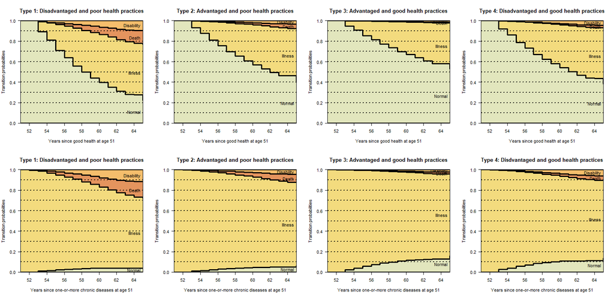

Table 6: Predicted transition probabilities of white males by age and chilhood type.

| by age | Type | 1 → 1 | 2 → 2 | 1 → 2 | 2 → 1 | 1 → 3 | 2 → 3 | 1 → 4 | 2 → 4 |
| --- | --- | --- | --- | --- | --- | --- | --- | --- | --- |
| 55 | Type 1 | 0.713 | 0.924 | 0.250 | 0.024 | 0.021 | 0.021 | 0.016 | 0.031 |
|  | Type 2 | 0.811 | 0.953 | 0.179 | 0.024 | 0.007 | 0.008 | 0.004 | 0.014 |
|  | Type 3 | 0.856 | 0.933 | 0.141 | 0.059 | 0.003 | 0.004 | 0.000 | 0.004 |
|  | Type 4 | 0.789 | 0.923 | 0.200 | 0.058 | 0.009 | 0.011 | 0.002 | 0.008 |
| 60 | Type 1 | 0.400 | 0.792 | 0.466 | 0.040 | 0.063 | 0.078 | 0.072 | 0.091 |
|  | Type 2 | 0.573 | 0.879 | 0.386 | 0.047 | 0.021 | 0.030 | 0.021 | 0.044 |
|  | Type 3 | 0.672 | 0.855 | 0.316 | 0.119 | 0.009 | 0.015 | 0.003 | 0.011 |
|  | Type 4 | 0.546 | 0.827 | 0.415 | 0.109 | 0.028 | 0.040 | 0.011 | 0.024 |
| 65 | Type 1 | 0.223 | 0.678 | 0.547 | 0.045 | 0.095 | 0.114 | 0.136 | 0.164 |
|  | Type 2 | 0.399 | 0.812 | 0.523 | 0.061 | 0.033 | 0.045 | 0.045 | 0.082 |
|  | Type 3 | 0.532 | 0.796 | 0.445 | 0.160 | 0.014 | 0.023 | 0.008 | 0.021 |
|  | Type 4 | 0.386 | 0.759 | 0.544 | 0.137 | 0.044 | 0.061 | 0.025 | 0.044 |
| Source: Author's calculation. Type 1: Disadvantaged childhoods and poor health practices. Type 2: Advantaged childhoods and poor health practices. Type 3: Advantaged childhoods and good health practic… |  |  |  |  |  |  |  |  |  |

Table 6 indicates similar patterns for the event of death before encountering disability by age $65$.

It is important to observe that the above reductions in disability enrollment rates from introduction of public policies are after taking into account that the policies would reduce the death rates, and thus increase the population susceptible to disability incidence after the introduction of such policies.

The improvements in health practices will also improve the scores of the biomarkers and thus the above improvements in probabilities will be even larger.

Furthermore, the public policies that turn a type 1 individual to a type 2 individual will also improve the likelihood of having normal health in the early middle ages from 0.313 to 0.346. This will also additionally reduce the probability of death before experiencing disability and the probability of experiencing disability even further.

Table 7: Probability of getting onto the disability rolls and death by age 65 for various gender-race group and childhood-types.

| group | Type | 1 → 1 | 2 → 2 | 1 → 2 | 2 → 1 | 1 → 3 | 2 → 3 | 1 → 4 | 2 → 4 |
| --- | --- | --- | --- | --- | --- | --- | --- | --- | --- |
| White Male | Type 1 | 0.220 | 0.676 | 0.547 | 0.044 | 0.097 | 0.115 | 0.136 | 0.165 |
|  | Type 2 | 0.397 | 0.811 | 0.525 | 0.061 | 0.033 | 0.045 | 0.046 | 0.083 |
|  | Type 3 | 0.530 | 0.797 | 0.448 | 0.159 | 0.014 | 0.023 | 0.008 | 0.021 |
|  | Type 4 | 0.383 | 0.759 | 0.546 | 0.135 | 0.045 | 0.061 | 0.026 | 0.045 |
| Non-White Male | Type 1 | 0.264 | 0.673 | 0.488 | 0.041 | 0.078 | 0.120 | 0.170 | 0.167 |
|  | Type 2 | 0.460 | 0.814 | 0.461 | 0.055 | 0.026 | 0.047 | 0.053 | 0.084 |
|  | Type 3 | 0.588 | 0.810 | 0.393 | 0.145 | 0.011 | 0.024 | 0.009 | 0.021 |
|  | Type 4 | 0.445 | 0.765 | 0.490 | 0.126 | 0.036 | 0.064 | 0.029 | 0.046 |
| White Female | Type 1 | 0.196 | 0.742 | 0.617 | 0.034 | 0.090 | 0.110 | 0.098 | 0.113 |
|  | Type 2 | 0.360 | 0.856 | 0.577 | 0.045 | 0.030 | 0.043 | 0.033 | 0.056 |
|  | Type 3 | 0.486 | 0.844 | 0.495 | 0.120 | 0.013 | 0.022 | 0.006 | 0.014 |
|  | Type 4 | 0.339 | 0.810 | 0.602 | 0.101 | 0.041 | 0.058 | 0.018 | 0.030 |
| Non-White Female | Type 1 | 0.247 | 0.739 | 0.557 | 0.032 | 0.074 | 0.115 | 0.122 | 0.114 |
|  | Type 2 | 0.428 | 0.857 | 0.510 | 0.042 | 0.024 | 0.045 | 0.038 | 0.056 |
|  | Type 3 | 0.549 | 0.854 | 0.434 | 0.109 | 0.010 | 0.023 | 0.006 | 0.015 |
|  | Type 4 | 0.404 | 0.814 | 0.542 | 0.095 | 0.034 | 0.060 | 0.021 | 0.031 |
| Source: Author's calculation. Type 1: Disadvantaged childhoods and poor health practices. Type 2: Advantaged childhoods and poor health practices. Type 3: Advantaged childhoods and good health practic… |  |  |  |  |  |  |  |  |  |

Regression coefficient estimates in Table 3 of Section 5.1 show that improvement in childhood SES has significant positive effects on childhood health, probability of college completion and probability of normal health in the early middle age. All these in turn have significant effects in lowering the probability of diseases, disability and death along the middle age health pathways. From policy perspective, it is important to examine which factors are relatively more important for cSES. To that end, note that cSES has polychoric correlations with the component variables (all are ordered categorical variables, with higher values mean better condition) as follows: family financial situation = 0.59, family moved for financial reason = 0.49, family usually got financial help during childhood = 0.40, father unemployed during childhood = 0.43, father’s usual occupation during childhood = 0.73, father’s education = 0.95, mother’s education = 0.84.

# 7 Conclusion

Identifying factors, stages of life and health practices that modulate health developments such as the incidence of chronic diseases, disability and mortality over one’s life cycle is important for social insurance programs like Social Security Disability Insurance (DI) and Supplemental Security Income (SSI) programs, and for public health programs. Along this line, the paper surveyed the microbiology literature and found a general consensus for the “developmental programming” mechanism for health development process over life cycle. According to this view, much of an individual’s later life health outcomes is programmed at an early stage of life, as early as the prenatal stage, and most importantly right after the conception stage. The programming is strongly modulated by the epigenetic inputs created by the environment in the mother’s womb, at post-natal early childhood stages and health behaviors throughout life. The genetic predisposition also matters. But, epigenetic factors modulate quite strongly the programming for later life developments in cognitive and non-cognitive health. The most important epigenetic factor is any kind of stress, including psychological, financial, social, and chemical stress. Other significant factors are diet, smoking, substance use, and exercising. These modulating factors are important throughout life, with stronger effects imparted in early stages of life.

This paper introduces a statistical multi-state time-to-event model, incorporating the above developmental programming mechanism and extending the existing disablement models from the disability literature. I use the Health and Retirement Survey (HRS) dataset to estimate the model. I use biomarkers BMI, CES-D and cognition scores as noisy measurements of depression and stress level, a measure of childhood socioeconomic status and childhood health as childhood factors, college graduation or higher education as a measure of cognitive health, smoking and exercising as health behaviors. I then study how these variables are related to the probabilities of following various transition paths through health states like normal health, illness with one-or-more chronic diseases, culminating in disability, or death. Disability, and death are treated as absorbing states.

The set of included regressors does not contain many of the genetic and epigenetic variables that modulate the heath development process over life cycle. These omitted variables will create frailty differences, i.e., unobserved heterogeneity among individuals given their observed characteristics (i.e., given the values of included variables). In general, the statistical estimates of the coefficients of the included regressors will be biased. For the two-state (i.e., alive-death) models, there are a few statistical estimation procedures that correct for the unobserved heterogeneity biases. For multi-state models, however, not much is available. The paper corrects for unobserved heterogeneity (or frailty) biases for the parameter estimates, extending a statistical procedure developed for two-state models to the present multi-state model; these bias corrected parameter estimates are used for inference and policy analysis in the paper.

The parameter estimates show that college graduates have significantly lower probability of all untoward transitions. The variable CES-D, measuring the level of depression and stress, has significant positive effects on the probability of transiting from normal health state to diseased health state, or to disability health state, and from diseased health state to disability health state, or to mortality health state. The other significant behavioral variables are smoking, and sufficiently vigorous exercising regularly. Smoking has significantly adverse effects, and exercising has favorable effects on probabilities of most transitions.

The paper finds that the childhood factors, biomarkers, and health behaviors are all (statistically) significantly associated with the probabilities of following various health pathways; consistent with the developmental programming hypothesis mentioned above, the childhood factors are found to be most important, especially the Childhood SES variable which is also found to have significant positive associations with childhood health, completed education level, and probability of normal health state prior to reaching age $51$. The statistically most significant estimate is for the coefficient of the variable CES-D, measuring the level of stress and depression. For instance, a $0.1$ unit increase in CES-D (the variable CES-D is measured in a scale of $−0.5$ to $0.5$) is associated with around 1.18 times higher probability of getting onto the disability program for individuals in normal health state, and around 1.1 times higher for individuals in diseased health state, holding all other factors constant. Out of all types of health behaviors, smoking has statistically significant strong positive association, and regular exercising has negative association with the probabilities of diseases, disability, and death.

The paper quantitatively estimates various policy effects on risks of getting onto the disability rolls, and death for various types of individuals. Individuals with low values of childhood factors are referred as having *disadvantaged childhood* and with high values of childhood factors as having *advantaged childhood*. They are further divided by the type of health practices they follow—good health practices or poor health practices—and by their initial early $50$s health state—normal or diseased. The paper considers public policies that turn a disadvantaged childhood individual into an advantaged childhood individual, public policies that help individuals follow good health practices or public policies that can achieve both.

For a disadvantaged childhood individual of normal initial health following poor health practices, the model predicts that policies that turn him to an advantaged individual without changes in his health practices will lower his probability of getting onto the disability rolls by age $65$ from around 0.095 to around 0.033. The policies that change him from following poor to good health practices without changes to his disadvantaged childhood status will lower the probability to about 0.044. Policies that change both his disadvantaged status and health practices, would lower the probability even further to about 0.014. It follows that the policies that improve health practices will also lower the risk of getting onto disability rolls of an advantaged individual following poor health practices by about 0.019.

Improvements of childhood factors involve policies for disadvantaged children to complete college (see Heckman (2008), Heckman and Raut (2016), and Raut (2018) among others for policies to that end) and to achieve better health involves improvements in healthcare access of the disadvantaged children. The policies that bring changes in health behaviors will involve public health education and regulations in food industry (see, Mozaffarian (2016), Timpel et al. (2019), and Budreviciute et al. (2020) among others). The latter type of policies are relatively more difficult to design and implement. Even only with policies that improve the childhood factors for disadvantaged children, some of the children will also have improvements in their biomarkers, health behaviors, and the likelihood of having normal health in their early middle ages. These will additionally lower the probability of getting onto the disability rolls and the probability of death in the population.

# Appendix:

Table 8: Unobserved heterogeneity bias corrected estimates of Cox regression models with childhood factors, biomarkers, and health behaviors - common random effect across transitions.

|  | 1 → 2 | 1 → 3 | 1 → 4 | 2 → 1 | 2 → 3 | 2 → 4 |
| --- | --- | --- | --- | --- | --- | --- |
| White | 0.198 *** | 0.412 | -0.455 | 0.158 * | -0.046 | -0.002 |
|  | (0.043) | (0.217) | (0.244) | (0.070) | (0.077) | (0.093) |
| Female | 0.099 * | -0.163 | -0.325 | -0.286 *** | -0.072 | -0.415 *** |
|  | (0.035) | (0.192) | (0.243) | (0.060) | (0.072) | (0.086) |
| Childhood SES | -0.210 *** | -0.177 | 0.047 | -0.051 | -0.222 * | -0.088 |
|  | (0.038) | (0.223) | (0.268) | (0.065) | (0.088) | (0.099) |
| Childhood Health | -0.139 ** | -0.155 | -0.828 *** | -0.019 | -0.008 | -0.411 *** |
|  | (0.042) | (0.210) | (0.238) | (0.068) | (0.078) | (0.088) |
| College+ | -0.038 | -0.805 * | -0.783 * | 0.047 | -0.774 *** | -0.266 * |
|  | (0.042) | (0.322) | (0.392) | (0.072) | (0.125) | (0.124) |
| CES-D | 0.550 *** | 1.589 *** | 0.505 | -0.431 ** | 1.022 *** | 0.596 *** |
|  | (0.083) | (0.331) | (0.501) | (0.131) | (0.117) | (0.146) |
| Total cognitive scores | 0.006 | -0.076 *** | -0.028 | -0.002 | -0.009 | -0.001 |
|  | (0.004) | (0.020) | (0.026) | (0.007) | (0.008) | (0.010) |
| High BMI | 0.264 *** | 0.050 | -0.062 | -0.474 *** | -0.013 | -0.217 * |
|  | (0.036) | (0.187) | (0.232) | (0.060) | (0.080) | (0.091) |
| Behavior: Smoking | 0.131 *** | 0.639 ** | 1.305 *** | -0.042 | 0.361 *** | 0.646 *** |
|  | (0.035) | (0.206) | (0.309) | (0.059) | (0.077) | (0.098) |
| Behavior: Exercising | 0.145 ** | -0.195 | -1.010 *** | 0.362 *** | -0.331 *** | -0.920 *** |
|  | (0.043) | (0.204) | (0.229) | (0.071) | (0.072) | (0.085) |
| #obs | 6482 | 6482 | 6482 | 14211 | 14211 | 14211 |
| #events | 3534 | 124 | 79 | 1235 | 841 | 593 |
| θ | 0.284 |  |  |  |  |  |
| χ² | 503.22 |  |  |  |  |  |
| χ²-pvalue | 0.00 |  |  |  |  |  |
| R² | 0.025 | 0.013 | 0.013 | 0.011 | 0.017 | 0.019 |
| logLik | -28700.592 | -970.834 | -607.249 | -11257.362 | -7628.676 | -5353.046 |
| AIC | 57421.183 | 1961.667 | 1234.497 | 22534.723 | 15277.353 | 10726.092 |
| Notes: *** p < 0.001; ** p < 0.01; * p < 0.05. Standard errors are in parenthesis. The statistic χ² is for testing the null hypothesis, H₀: θ = 0, i.e., no unobserved heterogeneity and χ²-pvalue is it… |  |  |  |  |  |  |

# References

Aalen, Odd O., Ørnulf Borgan, and Håkon K. Gjessing. 2008. *Survival and Event History Analysis*. Survival Analysis, Stochastic Process. Springer New York. https://doi.org/10.1007/978-0-387-68560-1.

Aalen, Odd O., and Søren Johansen. 1978. “An Empirical Transition Matrix for Non-Homogeneous Markov Chains Based on Censored Observations.” Duration, mult-state, counting process. *Scandinavian Journal of Statistics* 5 (3): 141–50. http://www.jstor.org/stable/4615704.

Aalen, Odd O., Morten Valberg, Tom Grotmol, and Steinar Tretli. 2014. “Understanding Variation in Disease Risk: The Elusive Concept of Frailty.” Frailty, duration. *International Journal of Epidemiology* 44 (4): 1408–21. https://doi.org/10.1093/ije/dyu192.

Albrecht, Gary L., and Lois M. Verbrugge. 2003. “The Global Emergence of Disability.” In *Handbook of Social Studies in Health and Medicine*, edited by Gary L Albrecht, Ray Fitzpatrick, and Susan C Scrimshaw, 293–307. London: Sage.

Alisch, R. S., B. G. Barwick, P. Chopra, L. K. Myrick, G. A. Satten, K. N. Conneely, and S. T. Warren. 2012. “Age-Associated DNA Methylation in Pediatric Populations.” *Genome Research* 22 (4): 623–32. https://doi.org/10.1101/gr.125187.111.

Altman, Barbara M. 2001. “Definitions, Models, Classifications, Schemes, and Applications.” In *Handbook of Disability Studies*, 97–122. SAGE Publications, Inc. https://doi.org/10.4135/9781412976251.n4.

An, Xinming, and Yiu-Fai Yung. 2014. “Item Response Theory: What It Is and How You Can Use the IRT Procedure to Apply It.” DFA, IRT, SAS. *SAS Institute Inc. SAS364-2014*. https://pdfs.semanticscholar.org/d85a/7025441f5685b287b53234ce6456dcd40192.pdf.

Andersen, Per Kragh, Ørnulf Borgan, Richard D. Gill, and Niels Keiding. 1993. *Statistical Models Based on Counting Processes*. Survival Analysis, Multi-state. Springer-Verlag, New York. https://doi.org/10.1007/978-1-4612-4348-9.

Andersen, Per Kragh, and Maja Pohar Perme. 2008. “Inference for Outcome Probabilities in Multi-State Models.” Duation Analysis. *Lifetime Data Analysis* 14 (4): 405–31. https://doi.org/10.1007/s10985-008-9097-x.

Barbara, Maria Andria, Ylenia Abdilla, and Jean Calleja-Agius. 2017. “An Introduction to Epigenetics.” *Neonatal Network* 36 (3): 124–28. https://doi.org/10.1891/0730-0832.36.3.124.

Barker, David J. P. 1990. “The Fetal and Infant Origins of Adult Disease.” *BMJ: British Medical Journal* 301 (6761): 1111.

———. 1998. “In Utero Programming of Chronic Disease.” *Clinical Science* 95 (2): 115–28. https://doi.org/10.1042/cs0950115.

———. 2007. “The Origins of the Developmental Origins Theory.” Developmental origin of health. *Journal of Internal Medicine* 261 (5): 412–17. https://doi.org/10.1111/j.1365-2796.2007.01809.x.

Barondes, Samuel. 1999. *Molecules and Mental Illness*. Scientific American Library.

Barres, Romain, and Juleen R Zierath. 2011. “DNA methylation in metabolic disorders.” *The American Journal of Clinical Nutrition* 93 (4): 897S–900S. https://doi.org/10.3945/ajcn.110.001933.

Bedirhan, Otsun T, Somnath Chatterji, Nenad Kostanjsek, Jorgen Rehm, Cille Kennedy, Joanne Epping-Jordan, Shekhar Saxena, Michael von Korff, and Charles Pull. 2010. “Developing the World Health Organization Disability Assessment Schedule 2.0.” *Bulletin of the World Health Organization* 88 (11): 815–23. https://doi.org/10.2471/blt.09.067231.

Boks, Marco P., Eske M. Derks, Daniel J. Weisenberger, Erik Strengman, Esther Janson, Iris E. Sommer, René S. Kahn, and Roel A. Ophoff. 2009. “The Relationship of DNA Methylation with Age, Gender and Genotype in Twins and Healthy Controls.” Edited by Joseph Najbauer. *PLoS ONE* 4 (8): e6767. https://doi.org/10.1371/journal.pone.0006767.

Bookman, Ebony B., Kimberly McAllister, Elizabeth Gillanders, Kay Wanke, David Balshaw, Joni Rutter, Jill Reedy, et al. 2011. “Gene-Environment Interplay in Common Complex Diseases: Forging an Integrative Model-Recommendations from an NIH Workshop.” *Genetic Epidemiology*. https://doi.org/10.1002/gepi.20571.

Budreviciute, Aida, Samar Damiati, Dana Khdr Sabir, Kamil Onder, Peter Schuller-Goetzburg, Gediminas Plakys, Agne Katileviciute, Samir Khoja, and Rimantas Kodzius. 2020. “Management and Prevention Strategies for Non-Communicable Diseases (NCDs) and Their Risk Factors.” *Frontiers in Public Health* 8 (November). https://doi.org/10.3389/fpubh.2020.574111.

Bugliari, Delia, Nancy Campbell, Chris Chan, Orla Hayden, Michael Hurd, Regan Main, Joshua Mallett, et al. 2016. “RAND HRS Data Documentation, Version p.” Technical report. RAND Center for the Study of Aging. https://www.rand.org/content/dam/rand/www/external/labor/aging/dataprod/randhrs1992_2014v2.pdf.

Cai, Li, Kilchan Choi, Mark Hansen, and Lauren Harrell. 2016. “Item Response Theory.” IRT. *Annual Review of Statistics and Its Application* 3 (1): 297–321. https://doi.org/10.1146/annurev-statistics-041715-033702.

Case, Anne, and Angus Deaton. 2015. “Rising Morbidity and Mortality in Midlife Among White Non-Hispanic Americans in the 21st Century.” *Proceedings of the National Academy of Sciences* 112 (49): 15078–83. https://doi.org/10.1073/pnas.1518393112.

Commenges, D. 2002. “Inference for Multi-State Models from Interval-Censored Data.” *Statistical Methods in Medical Research* 11 (2): 167–82. https://doi.org/10.1191/0962280202sm279ra.

Conti, Rena M., Ernst R. Berndt, and Richard G. Frank. 2009. “Early Retirement and DI/SSI Applications: Exploring the Impact of Depression.” CESD, HRS, Disability. In *Health at Older Ages: The Causes and Consequences of Declining Disability Among the Elderly*, 381–408. NBER Chapters. National Bureau of Economic Research, Inc. http://www.nber.org/chapters/c11120.pdf.

Cook, Richard J., and Jerald F. Lawless. 2018. *Multistate Models for the Analysis of Life History Data*. Frailty, duration, Multi-state. Chapman; Hall/CRC. https://doi.org/10.1201/9781315119731.

DiLoreto, Race, and Coleen T. Murphy. 2015. “The Cell Biology of Aging.” Biology of Aging. Edited by William Bement. *Molecular Biology of the Cell* 26 (25): 4524–31. https://doi.org/10.1091/mbc.e14-06-1084.

Elbers, Chris, and Geert Ridder. 1982. “True and Spurious Duration Dependence: The Identifiability of the Proportional Hazard Model.” Frailty, duration. *The Review of Economic Studies* 49 (3): 403–9. https://doi.org/10.2307/2297364.

Epel, Elissa S., Elizabeth H. Blackburn, Jue Lin, Firdaus S. Dhabhar, Nancy E. Adler, Jason D. Morrow, and Richard M. Cawthon. 2004. “Accelerated Telomere Shortening in Response to Life Stress.” *Proceedings of the National Academy of Sciences* 101 (49): 17312–15. https://doi.org/10.1073/pnas.0407162101.

Esteller, Manel. 2008. “Epigenetics in Cancer.” Cancer, Epigenetics. *New England Journal of Medicine* 358 (11): 1148–59. https://doi.org/10.1056/nejmra072067.

Fisher, Gwenith G, and Lindsay H Ryan. 2017. “Overview of the Health and Retirement Study and Introduction to the Special Issue.” HRS. Edited by Mo Wang. *Work, Aging and Retirement* 4 (1): 1–9. https://doi.org/10.1093/workar/wax032.

Fleming, Thomas R. 1978. “Nonparametric Estimation for Nonhomogeneous Markov Processes in the Problem of Competing Risks.” Duration, mult-state, counting process. *The Annals of Statistics* 6 (5): 1057–70. http://www.jstor.org/stable/2958608.

Fleming, Thomas R., and David P. Harrington. 2005. *Counting Processes and Survival Analysis*. Survival Analysis, Stochastic Process. Wiley.

Gluckman, Peter D., Mark A. Hanson, Cyrus Cooper, and Kent L. Thornburg. 2008. “Effect of in Utero and Early-Life Conditions on Adult Health and Disease.” Early Childhood events, Health, Epigenetics. *New England Journal of Medicine* 359 (1): 61–73. https://doi.org/10.1056/nejmra0708473.

Hahn, Harlan. 1985. “Toward a Politics of Disability: Definitions, Disciplines, and Policies.” *The Social Science Journal*. https://www.independentliving.org/docs4/hahn2.html.

Hannum, Gregory, Justin Guinney, Ling Zhao, Li Zhang, Guy Hughes, SriniVas Sadda, Brandy Klotzle, et al. 2013. “Genome-Wide Methylation Profiles Reveal Quantitative Views of Human Aging Rates.” Biological Age measure. *Molecular Cell* 49 (2): 359–67. https://doi.org/10.1016/j.molcel.2012.10.016.

Heckman, James J. 2008. “Schools, Skills and Synapses.” *Economic Inquiry* 46 (3): 289–324. https://doi.org/10.1111/j.1465-7295.2008.00163.x.

Heckman, James J., and Lakshmi K. Raut. 2016. “Intergenerational Long-Term Effects of Preschool-Structural Estimates from a Discrete Dynamic Programming Model.” Published: Preschool. *Journal of Econometrics* 191 (1): 164–75. https://doi.org/10.1016/j.jeconom.2015.10.001.

Heckman, James J., and Burton Singer. 1983. “The Identification Problem in Econometric Models for Duration Data.” In *Advances in Econometrics*, 39–78. Cambridge University Press. https://doi.org/10.1017/cbo9781139052160.002.

———. 1984a. “A Method for Minimizing the Impact of Distributional Assumptions in Econometric Models for Duration Data.” *Econometrica* 52 (2): 271–320. https://doi.org/10.2307/1911491.

———. 1984b. “The Identifiability of the Proportional Hazard Model.” *The Review of Economic Studies* 51 (2): 231–41. https://doi.org/10.2307/2297689.

Horvath, Steve. 2013. “DNA Methylation Age of Human Tissues and Cell Types.” Biological Age measure. *Genome Biology* 14 (10): 3156. https://doi.org/10.1186/gb-2013-14-10-r115.

Institute of Medicine. 2007. *Improving the Social Security Disability Decision Process*. Edited by John D. Stobo, Michael McGeary, and David K. Barnes. Washington, DC: The National Academies Press. https://doi.org/10.17226/11859.

Juster, F. Thomas, and Richard Suzman. 1995. “An Overview of the Health and Retirement Study.” HRS, overview. *The Journal of Human Resources* 30: S7. https://doi.org/10.2307/146277.

Kanherkar, Riya R., Naina Bhatia-Dey, and Antonei B. Csoka. 2014. “Epigenetics Across the Human Lifespan.” *Frontiers in Cell and Developmental Biology* 2 (3): 124–28. https://doi.org/10.3389/fcell.2014.00049.

Karakus, Mustafa C., and Lisa C. Patton. 2011. “Depression and the Onset of Chronic Illness in Older Adults: A 12-Year Prospective Study.” *The Journal of Behavioral Health Services & Research* 38 (3): 373–82. https://doi.org/10.1007/s11414-011-9234-2.

Khoury, Muin J., Lars Bertram, Paolo Boffetta, Adam S. Butterworth, Stephen J. Chanock, Siobhan M. Dolan, Isabel Fortier, et al. 2009. “Genome-Wide Association Studies, Field Synopses, and the Development of the Knowledge Base on Genetic Variation and Human Diseases.” *American Journal of Epidemiology* 170 (3): 269–79. https://doi.org/10.1093/aje/kwp119.

Luo, Ye, and Linda J. Waite. 2005. “The Impact of Childhood and Adult SES on Physical, Mental, and Cognitive Well-Being in Later Life.” *The Journals of Gerontology: Series B* 60 (2): S93–101. https://doi.org/10.1093/geronb/60.2.s93.

Marks, Deborah. 1997. “Models of Disability.” *Disability and Rehabilitation* 19 (3): 85–91. https://doi.org/10.3109/09638289709166831.

Mozaffarian, Dariush. 2016. “Dietary and Policy Priorities for Cardiovascular Disease, Diabetes, and Obesity.” *Circulation* 133 (2): 187–225. https://doi.org/10.1161/circulationaha.115.018585.

Nagi, Saad Z. 1965. “Some Conceptual Issues in Disability and Rehabilitation.” In *Sociology and Rehabilitation*, edited by M B Sussman. 100-113: American Sociological Association. https://ci.nii.ac.jp/naid/10015569425/en/.

———. 1976. “An Epidemiology of Disability Among Adults in the United States.” *The Milbank Memorial Fund Quarterly. Health and Society* 54 (4): 439. https://doi.org/10.2307/3349677.

———. 1991. “Disability in America: Toward a National Agenda for Prevention.” In, edited by Andrew M. Pope and Alvin R. Tarlov, 309–27. Washington, DC: National Academies Press. https://doi.org/10.17226/1579.

Pope, Andrew M., and Alvin R. Tarlov. 1991. *Disability in America: Toward a National Agenda for Prevention*. Edited by Andrew M. Pope and Alvin R. Tarlov. National Academies Press. https://doi.org/10.17226/1579.

Raut, Lakshmi K. 2017. “Exits from Disability: Estimates from a Competing Risk Model.” Published. *Social Security Bulletin* 77 (3): 15–38. https://doi.org/https://www.ssa.gov/policy/docs/ssb/v77n3/v77n3p15.html.

———. 2018. “Long-Term Effects of Preschool on School Performance, Earnings and Social Mobility.” *Studies in Microeconomics* 6 (1-2): 24–49. https://doi.org/10.1177/2321022218802023.

Renna, Francesco. 2008. “Alcohol Abuse, Alcoholism, and Labor Market Outcomes: Looking for the Missing Link.” *ILR Review* 62 (1): 92–103. https://doi.org/10.1177/001979390806200105.

Ripatti, Samuli, and Juni Palmgren. 2000. “Estimation of Multivariate Frailty Models Using Penalized Partial Likelihood.” Frailty, duration. *Biometrics* 56 (4): 1016–22. https://doi.org/https://doi.org/10.1111/j.0006-341X.2000.01016.x.

Seib, Charrlotte, Eliza Whiteside, Kathryn Lee, Janice Humphreys, Tiet Hanh Dao Tran, Lisa Chopin, and Debra Anderson. 2014. “Stress, Lifestyle, and Quality of Life in Midlife and Older Australian Women: Results from the Stress and the Health of Women Study.” *Women’s Health Issues* 24 (1): e43–52. https://doi.org/10.1016/j.whi.2013.11.004.

Shalev, Idan, and Jay Belsky. 2016. “Early-Life Stress and Reproductive Cost: A Two-Hit Developmental Model of Accelerated Aging?” Ageing Biology, Genetics,Neuroscience. *Medical Hypotheses* 90: 41–47. https://doi.org/10.1016/j.mehy.2016.03.002.

Shalev, Idan, Sonja Entringer, Pathik D. Wadhwa, Owen M. Wolkowitz, Eli Puterman, Jue Lin, and Elissa S. Epel. 2013. “Stress and Telomere Biology: A Lifespan Perspective.” *Psychoneuroendocrinology* 38 (9): 1835–42. https://doi.org/10.1016/j.psyneuen.2013.03.010.

Simons, Ronald L., Man Kit Lei, Steven R. H. Beach, Robert A. Philibert, Carolyn E. Cutrona, Frederick X. Gibbons, and Ashley Barr. 2016. “Economic Hardship and Biological Weathering: The Epigenetics of Aging in a U.S. Sample of Black Women.” Ageing Biology, Genetics,Neuroscience. *Social Science & Medicine* 150: 192–200. https://doi.org/10.1016/j.socscimed.2015.12.001.

Snyder, Alison R., John T. Parsons, Tamara C. Valovich McLeod, R. Curtis Bay, Lori A. Michener, and Eric L. Sauers. 2008. “Using Disablement Models and Clinical Outcomes Assessment to Enable Evidence-Based Athletic Training Practice, Part i: Disablement Models.” *Journal of Athletic Training* 43 (4): 428–36. https://doi.org/10.4085/1062-6050-43.4.428.

Sonnega, A., J. D. Faul, M. B. Ofstedal, K. M. Langa, J. W. Phillips, and D. R. Weir. 2014. “Cohort Profile: The Health and Retirement Study (HRS).” *International Journal of Epidemiology* 43 (2): 576–85. https://doi.org/10.1093/ije/dyu067.

Steffick, Diane E. 2000. “Documentation of Affective Functioning Measures in the Health and Retirement Study.” *Ann Arbor, MI: University of Michigan*. http://hrsonline.isr.umich.edu/sitedocs/userg/dr-005.pdf.

The US Burden of Disease Collaborators. 2018. “The State of US Health, 1990-2016: Burden of Diseases, Injuries, and Risk Factors Among US States.” *JAMA* 319 (14): 1444–72. https://doi.org/10.1001/jama.2018.0158.

Therneau, Terry M. 2022. “Mixed Effects Cox Models.” Frailty, duration. *CRAN Repository*. https://cran.r-project.org/web/packages/coxme/vignettes/coxme.pdf.

Thornburg, Kent L., Jackilen Shannon, Philippe Thuillier, and Mitchell S. Turker. 2010. “In Utero Life and Epigenetic Predisposition for Disease.” Early Childhood events, Health, Epigenetics. In *Epigenetics and Cancer, Part b*, 57–78. Elsevier. https://doi.org/10.1016/b978-0-12-380864-6.00003-1.

Timpel, Patrick, Lorenz Harst, Doreen Reifegerste, Susann Weihrauch-Blüher, and Peter E. H. Schwarz. 2019. “What Should Governments Be Doing to Prevent Diabetes Throughout the Life Course?” Health and Disability, Public policies. *Diabetologia* 62 (10): 1842–53. https://doi.org/10.1007/s00125-019-4941-y.

Vable, Anusha M., Paola Gilsanz, Thu T. Nguyen, Ichiro Kawachi, and M. Maria Glymour. 2017. “Validation of a Theoretically Motivated Approach to Measuring Childhood Socioeconomic Circumstances in the Health and Retirement Study.” IRT, SES, HRS. Edited by Abigail Fraser. *PLOS ONE* 12 (10): e0185898. https://doi.org/10.1371/journal.pone.0185898.

Vaupel, James W., Kenneth G. Manton, and Eric Stallard. 1979. “The Impact of Heterogeneity in Individual Frailty on the Dynamics of Mortality.” Frailty, duration. *Demography* 16 (3): 439–54. https://doi.org/10.2307/2061224.

Verbrugge, Lois M., and Alan M. Jette. 1994. “The Disablement Process.” Disablement Process. *Social Science & Medicine* 38 (1): 1–14. https://doi.org/10.1016/0277-9536(94)90294-1.

Verbrugge, Lois M., Kenzie Latham, and Philippa J. Clarke. 2017. “Aging with Disability for Midlife and Older Adults.” *Research on Aging* 39 (6): 741–77. https://doi.org/10.1177/0164027516681051.

World Health Organization. 2001. “International Classification of Functioning, Disability and Health.” Technical report. Geneva: World Health Organization. https://psychiatr.ru/download/1313?view=name=CF_18.pdf.

Wreede, Liesbeth C. de, Marta Fiocco, and Hein Putter. 2010. “The Mstate Package for Estimation and Prediction in Non- and Semi-Parametric Multi-State and Competing Risks Models.” Duation Analysis. *Computer Methods and Programs in Biomedicine* 99 (3): 261–74. https://doi.org/10.1016/j.cmpb.2010.01.001.

## Footnotes

[^1]: This paper is dedicated in loving memory of my younger brother, Bishnu Pada Raut, who passed away in New Delhi on February 1, 2019, from lung cancer. He never smoked, never drank, and had normal BMI, CES-D and other standard biomarkers (personally observed) throughout his life. Why are there incidence of diseases and death at premature ages? Scientific community is actively exploring the answers to these questions and the ways to improve life. This paper is an inquiry in this vein. Earlier drafts were presented at the 2019 Annual Conference of the Society for Government Economists, April 5, 2019, Washington, DC; Indian Statistical Institute, Kolkata; and Delhi School of Economics, New Delhi, India. I had many insightful comments from Han Altae-Tran at MIT, Elizabeth Bass at Congressional Budget Office, John Phillips at NIH, and Robert Weathers at SSA and audiences of the conference and seminars. Thanks.
[^2]: For details, see https://www.ssa.gov/OP_Home/ssact/title02/0223.htm section 223(d)(2) for the OASDI program, and https://www.ssa.gov/OP_Home/ssact/title16b/1614.htm paragraph 3(A) for the SSI program.
[^3]: Nagi model has been adapted by the World Health Organization in their classification scheme of disability, the latest one is World Health Organization (2001). See Bedirhan et al. (2010) for an application of the above disablement models in WHO’s 2001 classification system, and see (Pope and Tarlov 1991; Institute of Medicine 2007) for more on this.
[^4]: The probability of recovery depends on the type of disability, and it is very small as estimates in Raut (2017) show using the SSA’s administrative data.
[^5]: For a derivation,see Andersen et al. (1993), Andersen and Perme (2008), Commenges (2002), or Cook and Lawless (2018).
[^6]: Fleming gave the estimator for complete data, Aalen and Johansen gave the estimator for censored data.
[^7]: *Marginal likelihood function* is the expectation of the conditional likelihood function given frailty level over the distribution of the frailty. This is also known as the *mixture likelihood function*.
[^8]: The specification in both Ripatti and Palmgren (2000) and Therneau (2022) are more general. The framework is capable of estimating shared frailty models, groups of records sharing common frailties by specifying appropriate design vectors for the frailty term in Equation 6.
[^9]: When $G(.)$ is a gamma distribution, with mean $1$ and variance $\theta$, one can derive that $\mathcal{L}(c)=(1+\theta c)^{-1/\theta}$.
[^10]: Genetic make-up also controls gene expressions for producing proteins that create diseases but the epigenetic factors creating the stressors are important as well.